## R Code for Chapter 17. Exploratory Factor Analysis

```r
#Install Packages

#install.packages("corpcor")
#install.packages("GPArotation")
#install.packages("psych")
#install.packages("pastecs")
```

```r
#Load these packages, along with the boot package.
library(corpcor)
library(GPArotation)
library(psych)
```

#### The R anxiety questionnaire(RAQ) Example

raq.dat: designed to predict how anxious a given individual would be about learning how to use R (FIGURE 17.6) consists of 23 questionaire from score 1~5

```r
#Set the working directory
setwd("~/Documents/Study/DSUR/aall_data_files")

#load data
raqData<-read.delim("raq.dat", header = TRUE)
```

```r
#create a correlation matrix
raqMatrix<-cor(raqData)
round(raqMatrix, 2)
```

```
##       Q01   Q02   Q03   Q04   Q05   Q06   Q07   Q08   Q09   Q10   Q11
## Q01  1.00 -0.10 -0.34  0.44  0.40  0.22  0.31  0.33 -0.09  0.21  0.36
## Q02 -0.10  1.00  0.32 -0.11 -0.12 -0.07 -0.16 -0.05  0.31 -0.08 -0.14
## Q03 -0.34  0.32  1.00 -0.38 -0.31 -0.23 -0.38 -0.26  0.30 -0.19 -0.35
## Q04  0.44 -0.11 -0.38  1.00  0.40  0.28  0.41  0.35 -0.12  0.22  0.37
## Q05  0.40 -0.12 -0.31  0.40  1.00  0.26  0.34  0.27 -0.10  0.26  0.30
## Q06  0.22 -0.07 -0.23  0.28  0.26  1.00  0.51  0.22 -0.11  0.32  0.33
## Q07  0.31 -0.16 -0.38  0.41  0.34  0.51  1.00  0.30 -0.13  0.28  0.34
## Q08  0.33 -0.05 -0.26  0.35  0.27  0.22  0.30  1.00  0.02  0.16  0.63
## Q09 -0.09  0.31  0.30 -0.12 -0.10 -0.11 -0.13  0.02  1.00 -0.13 -0.12
## Q10  0.21 -0.08 -0.19  0.22  0.26  0.32  0.28  0.16 -0.13  1.00  0.27
## Q11  0.36 -0.14 -0.35  0.37  0.30  0.33  0.34  0.63 -0.12  0.27  1.00
## Q12  0.35 -0.19 -0.41  0.44  0.35  0.31  0.42  0.25 -0.17  0.25  0.34
## Q13  0.35 -0.14 -0.32  0.34  0.30  0.47  0.44  0.31 -0.17  0.30  0.42
## Q14  0.34 -0.16 -0.37  0.35  0.32  0.40  0.44  0.28 -0.12  0.25  0.33
## Q15  0.25 -0.16 -0.31  0.33  0.26  0.36  0.39  0.30 -0.19  0.30  0.36
## Q16  0.50 -0.17 -0.42  0.42  0.39  0.24  0.39  0.32 -0.19  0.29  0.37
## Q17  0.37 -0.09 -0.33  0.38  0.31  0.28  0.39  0.59 -0.04  0.22  0.59
## Q18  0.35 -0.16 -0.38  0.38  0.32  0.51  0.50  0.28 -0.15  0.29  0.37
## Q19 -0.19  0.20  0.34 -0.19 -0.17 -0.17 -0.27 -0.16  0.25 -0.13 -0.20
## Q20  0.21 -0.20 -0.32  0.24  0.20  0.10  0.22  0.18 -0.16  0.08  0.26
## Q21  0.33 -0.20 -0.42  0.41  0.33  0.27  0.48  0.30 -0.14  0.19  0.35
## Q22 -0.10  0.23  0.20 -0.10 -0.13 -0.17 -0.17 -0.08  0.26 -0.13 -0.16
## Q23  0.00  0.10  0.15 -0.03 -0.04 -0.07 -0.07 -0.05  0.17 -0.06 -0.09
##       Q12   Q13   Q14   Q15   Q16   Q17   Q18   Q19   Q20   Q21   Q22
## Q01  0.35  0.35  0.34  0.25  0.50  0.37  0.35 -0.19  0.21  0.33 -0.10
## Q02 -0.19 -0.14 -0.16 -0.16 -0.17 -0.09 -0.16  0.20 -0.20 -0.20  0.23
## Q03 -0.41 -0.32 -0.37 -0.31 -0.42 -0.33 -0.38  0.34 -0.32 -0.42  0.20
## Q04  0.44  0.34  0.35  0.33  0.42  0.38  0.38 -0.19  0.24  0.41 -0.10
## Q05  0.35  0.30  0.32  0.26  0.39  0.31  0.32 -0.17  0.20  0.33 -0.13
## Q06  0.31  0.47  0.40  0.36  0.24  0.28  0.51 -0.17  0.10  0.27 -0.17
## Q07  0.42  0.44  0.44  0.39  0.39  0.39  0.50 -0.27  0.22  0.48 -0.17
## Q08  0.25  0.31  0.28  0.30  0.32  0.59  0.28 -0.16  0.18  0.30 -0.08
## Q09 -0.17 -0.17 -0.12 -0.19 -0.19 -0.04 -0.15  0.25 -0.16 -0.14  0.26
## Q10  0.25  0.30  0.25  0.30  0.29  0.22  0.29 -0.13  0.08  0.19 -0.13
## Q11  0.34  0.42  0.33  0.36  0.37  0.59  0.37 -0.20  0.26  0.35 -0.16
## Q12  1.00  0.49  0.43  0.33  0.41  0.33  0.49 -0.27  0.30  0.44 -0.17
## Q13  0.49  1.00  0.45  0.34  0.36  0.41  0.53 -0.23  0.20  0.37 -0.20
## Q14  0.43  0.45  1.00  0.38  0.42  0.35  0.50 -0.25  0.23  0.40 -0.17
## Q15  0.33  0.34  0.38  1.00  0.45  0.37  0.34 -0.21  0.21  0.30 -0.17
```

[output cut: 17 more lines]

```
## Q09  0.17
## Q10 -0.06
## Q11 -0.09
## Q12 -0.05
## Q13 -0.05
## Q14 -0.05
## Q15 -0.06
## Q16 -0.08
## Q17 -0.09
## Q18 -0.08
## Q19  0.12
## Q20 -0.03
## Q21 -0.07
## Q22  0.23
## Q23  1.00
```

Analysis process

1. Scan the matrix for correlations > 0.3,
2. Look for variables that only have a small number of correlations greater than this value.
3. Scan the correlation coefficients themselves and look for any greater than .9.
4. Any are found then you should be aware that a problem could arise because of linearity in the data.

```r
#Break down the matrix to make it easier to put in the book
round(raqMatrix[,1:8], 2)
```

```
##       Q01   Q02   Q03   Q04   Q05   Q06   Q07   Q08
## Q01  1.00 -0.10 -0.34  0.44  0.40  0.22  0.31  0.33
## Q02 -0.10  1.00  0.32 -0.11 -0.12 -0.07 -0.16 -0.05
## Q03 -0.34  0.32  1.00 -0.38 -0.31 -0.23 -0.38 -0.26
## Q04  0.44 -0.11 -0.38  1.00  0.40  0.28  0.41  0.35
## Q05  0.40 -0.12 -0.31  0.40  1.00  0.26  0.34  0.27
## Q06  0.22 -0.07 -0.23  0.28  0.26  1.00  0.51  0.22
## Q07  0.31 -0.16 -0.38  0.41  0.34  0.51  1.00  0.30
## Q08  0.33 -0.05 -0.26  0.35  0.27  0.22  0.30  1.00
## Q09 -0.09  0.31  0.30 -0.12 -0.10 -0.11 -0.13  0.02
## Q10  0.21 -0.08 -0.19  0.22  0.26  0.32  0.28  0.16
## Q11  0.36 -0.14 -0.35  0.37  0.30  0.33  0.34  0.63
## Q12  0.35 -0.19 -0.41  0.44  0.35  0.31  0.42  0.25
## Q13  0.35 -0.14 -0.32  0.34  0.30  0.47  0.44  0.31
## Q14  0.34 -0.16 -0.37  0.35  0.32  0.40  0.44  0.28
## Q15  0.25 -0.16 -0.31  0.33  0.26  0.36  0.39  0.30
## Q16  0.50 -0.17 -0.42  0.42  0.39  0.24  0.39  0.32
## Q17  0.37 -0.09 -0.33  0.38  0.31  0.28  0.39  0.59
## Q18  0.35 -0.16 -0.38  0.38  0.32  0.51  0.50  0.28
## Q19 -0.19  0.20  0.34 -0.19 -0.17 -0.17 -0.27 -0.16
## Q20  0.21 -0.20 -0.32  0.24  0.20  0.10  0.22  0.18
## Q21  0.33 -0.20 -0.42  0.41  0.33  0.27  0.48  0.30
## Q22 -0.10  0.23  0.20 -0.10 -0.13 -0.17 -0.17 -0.08
## Q23  0.00  0.10  0.15 -0.03 -0.04 -0.07 -0.07 -0.05
```

```r
round(raqMatrix[,9:16], 2)
```

```
##       Q09   Q10   Q11   Q12   Q13   Q14   Q15   Q16
## Q01 -0.09  0.21  0.36  0.35  0.35  0.34  0.25  0.50
## Q02  0.31 -0.08 -0.14 -0.19 -0.14 -0.16 -0.16 -0.17
## Q03  0.30 -0.19 -0.35 -0.41 -0.32 -0.37 -0.31 -0.42
## Q04 -0.12  0.22  0.37  0.44  0.34  0.35  0.33  0.42
## Q05 -0.10  0.26  0.30  0.35  0.30  0.32  0.26  0.39
## Q06 -0.11  0.32  0.33  0.31  0.47  0.40  0.36  0.24
## Q07 -0.13  0.28  0.34  0.42  0.44  0.44  0.39  0.39
## Q08  0.02  0.16  0.63  0.25  0.31  0.28  0.30  0.32
## Q09  1.00 -0.13 -0.12 -0.17 -0.17 -0.12 -0.19 -0.19
## Q10 -0.13  1.00  0.27  0.25  0.30  0.25  0.30  0.29
## Q11 -0.12  0.27  1.00  0.34  0.42  0.33  0.36  0.37
## Q12 -0.17  0.25  0.34  1.00  0.49  0.43  0.33  0.41
## Q13 -0.17  0.30  0.42  0.49  1.00  0.45  0.34  0.36
## Q14 -0.12  0.25  0.33  0.43  0.45  1.00  0.38  0.42
## Q15 -0.19  0.30  0.36  0.33  0.34  0.38  1.00  0.45
## Q16 -0.19  0.29  0.37  0.41  0.36  0.42  0.45  1.00
## Q17 -0.04  0.22  0.59  0.33  0.41  0.35  0.37  0.41
## Q18 -0.15  0.29  0.37  0.49  0.53  0.50  0.34  0.42
## Q19  0.25 -0.13 -0.20 -0.27 -0.23 -0.25 -0.21 -0.27
## Q20 -0.16  0.08  0.26  0.30  0.20  0.23  0.21  0.27
## Q21 -0.14  0.19  0.35  0.44  0.37  0.40  0.30  0.42
## Q22  0.26 -0.13 -0.16 -0.17 -0.20 -0.17 -0.17 -0.16
## Q23  0.17 -0.06 -0.09 -0.05 -0.05 -0.05 -0.06 -0.08
```

```r
round(raqMatrix[,17:23], 2)
```

```
##       Q17   Q18   Q19   Q20   Q21   Q22   Q23
## Q01  0.37  0.35 -0.19  0.21  0.33 -0.10  0.00
## Q02 -0.09 -0.16  0.20 -0.20 -0.20  0.23  0.10
## Q03 -0.33 -0.38  0.34 -0.32 -0.42  0.20  0.15
## Q04  0.38  0.38 -0.19  0.24  0.41 -0.10 -0.03
## Q05  0.31  0.32 -0.17  0.20  0.33 -0.13 -0.04
## Q06  0.28  0.51 -0.17  0.10  0.27 -0.17 -0.07
## Q07  0.39  0.50 -0.27  0.22  0.48 -0.17 -0.07
## Q08  0.59  0.28 -0.16  0.18  0.30 -0.08 -0.05
## Q09 -0.04 -0.15  0.25 -0.16 -0.14  0.26  0.17
## Q10  0.22  0.29 -0.13  0.08  0.19 -0.13 -0.06
## Q11  0.59  0.37 -0.20  0.26  0.35 -0.16 -0.09
## Q12  0.33  0.49 -0.27  0.30  0.44 -0.17 -0.05
## Q13  0.41  0.53 -0.23  0.20  0.37 -0.20 -0.05
## Q14  0.35  0.50 -0.25  0.23  0.40 -0.17 -0.05
## Q15  0.37  0.34 -0.21  0.21  0.30 -0.17 -0.06
## Q16  0.41  0.42 -0.27  0.27  0.42 -0.16 -0.08
## Q17  1.00  0.38 -0.16  0.21  0.36 -0.13 -0.09
## Q18  0.38  1.00 -0.26  0.24  0.43 -0.16 -0.08
## Q19 -0.16 -0.26  1.00 -0.25 -0.27  0.23  0.12
## Q20  0.21  0.24 -0.25  1.00  0.47 -0.10 -0.03
## Q21  0.36  0.43 -0.27  0.47  1.00 -0.13 -0.07
## Q22 -0.13 -0.16  0.23 -0.10 -0.13  1.00  0.23
## Q23 -0.09 -0.08  0.12 -0.03 -0.07  0.23  1.00
```

**Bartlett’s test**

Examines whether the population correlation matrix resembles an identity matrix. (17.4.2)

=> Every variable correlates very badly with all other variables (all correlation coefficients =~ 0) => independent

```r
cortest.bartlett(raqData)
```

```
## $chisq
## [1] 19334
##
## $p.value
## [1] 0
##
## $df
## [1] 253
```

```r
cortest.bartlett(raqMatrix, n = 2571) #provide the sample size
```

```
## $chisq
## [1] 19334
##
## $p.value
## [1] 0
##
## $df
## [1] 253
```

Conclusion: Bartlett’s test is highly significant,X2(253) = 19,334,P< .001,and therefore factor analysis is appropriate.

**KMO test**

KMO (Kaiser-Meyer-Olkin) Measure of Sampling Adequacy at least >= 0.5 for a satisfactory factor analysis to proceed

Function by G. Jay Kerns, Ph.D., Youngstown State University (http://tolstoy.newcastle.edu.au/R/e2/help/07/08/22816.html)

```r
kmo = function( data ){
  library(MASS)
  X <- cor(as.matrix(data))
  iX <- ginv(X)
  S2 <- diag(diag((iX^-1)))
  AIS <- S2%*%iX%*%S2  # anti-image covariance matrix
  IS <- X+AIS-2*S2     # image covariance matrix
  Dai <- sqrt(diag(diag(AIS)))
  IR <- ginv(Dai)%*%IS%*%ginv(Dai) # image correlation matrix
  AIR <- ginv(Dai)%*%AIS%*%ginv(Dai) # anti-image correlation matrix
  a <- apply((AIR - diag(diag(AIR)))^2, 2, sum)
  AA <- sum(a)
  b <- apply((X - diag(nrow(X)))^2, 2, sum)
  BB <- sum(b)
  MSA <- b/(b+a)  # indiv. measures of sampling adequacy
  AIR <- AIR-diag(nrow(AIR))+diag(MSA)  # Examine the anti-image of the correlation matrix. That is the  negative of the partial correlations, partialling out all other variables.
  kmo <- BB/(AA+BB)  # overall KMO statistic
  # Reporting the conclusion
   if (kmo >= 0.00 && kmo < 0.50){test <- 'The KMO test yields a degree of common variance unacceptable for FA.'}
      else if (kmo >= 0.50 && kmo < 0.60){test <- 'The KMO test yields a degree of common variance miserable.'}
      else if (kmo >= 0.60 && kmo < 0.70){test <- 'The KMO test yields a degree of common variance mediocre.'}
      else if (kmo >= 0.70 && kmo < 0.80){test <- 'The KMO test yields a degree of common variance middling.' }
      else if (kmo >= 0.80 && kmo < 0.90){test <- 'The KMO test yields a degree of common variance meritorious.' }
       else { test <- 'The KMO test yields a degree of common variance marvelous.' }

       ans <- list( overall = kmo,
                  report = test,
                  individual = MSA,
                  AIS = AIS,
                  AIR = AIR )
    return(ans)
}
```

```r
#To use this function:
kmo(raqData)
```

```
## $overall
## [1] 0.9302
##
## $report
## [1] "The KMO test yields a degree of common variance marvelous."
##
## $individual
##    Q01    Q02    Q03    Q04    Q05    Q06    Q07    Q08    Q09    Q10
## 0.9298 0.8748 0.9510 0.9553 0.9601 0.8913 0.9417 0.8713 0.8337 0.9487
##    Q11    Q12    Q13    Q14    Q15    Q16    Q17    Q18    Q19    Q20
## 0.9059 0.9548 0.9482 0.9672 0.9404 0.9336 0.9306 0.9480 0.9407 0.8891
##    Q21    Q22    Q23
## 0.9293 0.8785 0.7664
##
## $AIS
```

[output cut: 194 more lines]

**Determinant : the ‘area’ of the data => determinant (area)=0: lowest correlation; 1: biggest.**

```r
#Determinent (execute one of these):
det(raqMatrix)
```

```
## [1] 0.0005271
```

```r
det(cor(raqData))
```

```
## [1] 0.0005271
```

**PCA**

General form

pcModel<-principal(dataframe/R-matrix, nfactors = number of factors, rotate = “method of rotation”, scores = TRUE)

nfactors: how many factors/components you want to extract (see tion 17.3.8) as a number. default: 1

rotate: a method of factor rotation (see section 17.3.9) using a text string. default: varimax rotation scores: obtain factor scores (TRUE) or not (FALSE). default: FALSE.

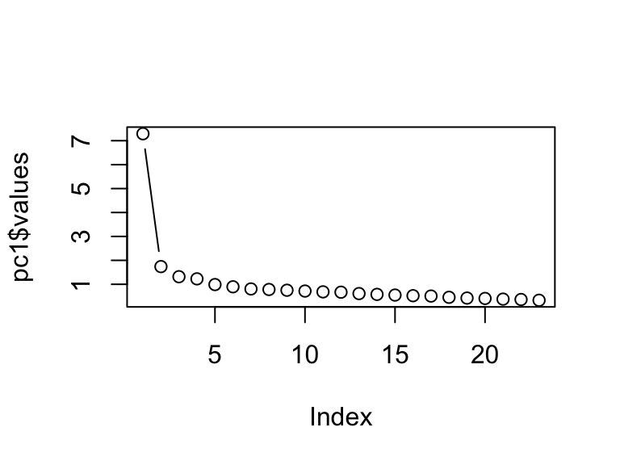

```r
pc1 <-  principal(raqData, nfactors = 23, rotate = "none") #from the raw data
#pc1 <- principal(raqMatrix, nfactors = 23, rotate = "none") #from the correlation matrix, same as above line
pc1 <-  principal(raqData, nfactors = length(raqData), rotate = "none")
plot(pc1$values, type = "b") #plots the eigenvalues (y) against the factor number (x), b: both a line and points on the same graph
```

```r
pc1
```

```
## Principal Components Analysis
## Call: principal(r = raqData, nfactors = length(raqData), rotate = "none")
## Standardized loadings (pattern matrix) based upon correlation matrix
##       PC1   PC2   PC3   PC4   PC5   PC6   PC7   PC8   PC9  PC10  PC11
## Q01  0.59  0.18 -0.22  0.12 -0.40 -0.11 -0.22 -0.08  0.01 -0.10  0.11
## Q02 -0.30  0.55  0.15  0.01 -0.03 -0.38  0.19 -0.39  0.01 -0.12  0.30
## Q03 -0.63  0.29  0.21 -0.07  0.02  0.00  0.01 -0.05  0.20  0.10  0.15
## Q04  0.63  0.14 -0.15  0.15 -0.20 -0.12 -0.06  0.11 -0.11 -0.01 -0.03
## Q05  0.56  0.10 -0.07  0.14 -0.42 -0.17 -0.06  0.11  0.24  0.09 -0.30
## Q06  0.56  0.10  0.57 -0.05  0.17  0.01  0.00  0.05  0.00  0.00 -0.13
## Q07  0.69  0.04  0.25  0.10  0.17 -0.08  0.05  0.03 -0.08  0.13 -0.27
## Q08  0.55  0.40 -0.32 -0.42  0.15  0.10 -0.07 -0.04  0.01 -0.05 -0.09
## Q09 -0.28  0.63 -0.01  0.10  0.17 -0.27 -0.01 -0.03  0.16  0.32 -0.22
## Q10  0.44  0.03  0.36 -0.10 -0.34  0.22  0.44 -0.03  0.37 -0.22 -0.11
## Q11  0.65  0.25 -0.21 -0.40  0.13  0.18 -0.01  0.03  0.10 -0.14  0.00
## Q12  0.67 -0.05  0.05  0.25  0.04 -0.08 -0.14  0.08  0.01 -0.11  0.19
## Q13  0.67  0.08  0.28 -0.01  0.13  0.03 -0.21  0.05  0.08 -0.22  0.24
## Q14  0.66  0.02  0.20  0.14  0.08 -0.03 -0.10 -0.06 -0.14  0.16  0.08
## Q15  0.59  0.01  0.12 -0.11 -0.07  0.29  0.32 -0.12 -0.27  0.41  0.15
## Q16  0.68  0.01 -0.14  0.08 -0.32  0.00  0.12 -0.14 -0.19  0.15  0.16
## Q17  0.64  0.33 -0.21 -0.34  0.10  0.05 -0.02  0.03 -0.04  0.02  0.01
## Q18  0.70  0.03  0.30  0.13  0.15 -0.09 -0.10  0.06 -0.06 -0.12  0.05
## Q19 -0.43  0.39  0.10 -0.01 -0.15  0.07  0.05  0.68  0.02  0.16  0.29
## Q20  0.44 -0.21 -0.40  0.30  0.33 -0.01  0.34  0.03  0.33  0.02  0.21
## Q21  0.66 -0.06 -0.19  0.28  0.24 -0.15  0.18  0.10  0.12  0.08 -0.02
## Q22 -0.30  0.47 -0.12  0.38  0.07  0.12  0.31  0.12 -0.41 -0.39 -0.19
## Q23 -0.14  0.37 -0.02  0.51  0.02  0.62 -0.28 -0.22  0.18  0.08  0.00
##      PC12  PC13  PC14  PC15  PC16  PC17  PC18  PC19  PC20  PC21  PC22
## Q01 -0.12  0.30 -0.25  0.18  0.12 -0.05 -0.17  0.16 -0.01 -0.21  0.05
## Q02  0.27 -0.02  0.01 -0.24 -0.05 -0.08  0.00  0.01 -0.02 -0.02  0.03
## Q03  0.03  0.10  0.13  0.40 -0.06  0.43  0.08  0.09  0.05  0.01  0.00
## Q04  0.34 -0.32 -0.17  0.12  0.31  0.19  0.05 -0.21  0.04  0.09 -0.02
## Q05  0.16  0.12  0.48 -0.07 -0.08 -0.04  0.01 -0.04  0.00 -0.02  0.02
## Q06  0.20  0.24 -0.03  0.08  0.20 -0.14  0.05  0.09 -0.07  0.04 -0.32
## Q07  0.20  0.04 -0.22  0.00 -0.23  0.03 -0.15  0.20  0.16  0.14  0.24
## Q08  0.03 -0.01  0.04 -0.04  0.03  0.10  0.07  0.12 -0.15  0.06  0.16
## Q09 -0.37 -0.17 -0.07  0.12  0.11 -0.19 -0.02 -0.08 -0.03  0.04 -0.01
## Q10 -0.21 -0.17 -0.15 -0.07  0.03  0.07 -0.01  0.00  0.04 -0.03  0.02
## Q11  0.03  0.02  0.03 -0.02  0.07 -0.05  0.07  0.07 -0.18  0.06  0.00
## Q12 -0.07 -0.45  0.17  0.09 -0.10 -0.08  0.04  0.36  0.00 -0.04 -0.10
```

[output cut: 47 more lines]

```
## Cumulative Proportion 0.75 0.78 0.80 0.83 0.85 0.88 0.90 0.92 0.94 0.95
##                       PC21 PC22 PC23
## SS loadings           0.38 0.36 0.33
## Proportion Var        0.02 0.02 0.01
## Cumulative Var        0.97 0.99 1.00
## Proportion Explained  0.02 0.02 0.01
## Cumulative Proportion 0.97 0.99 1.00
##
## Test of the hypothesis that 23 components are sufficient.
##
## The degrees of freedom for the null model are  253  and the objective function was  7.55
## The degrees of freedom for the model are -23  and the objective function was  0
## The total number of observations was  2571  with MLE Chi Square =  0  with prob <  NA
##
## Fit based upon off diagonal values = 1
```

```r
names(pc1)
```

```
##  [1] "values"       "rotation"     "n.obs"        "communality"
##  [5] "loadings"     "fit"          "fit.off"      "fn"
##  [9] "Call"         "uniquenesses" "R2"           "objective"
## [13] "residual"     "factors"      "dof"          "null.dof"
## [17] "null.model"   "criteria"     "STATISTIC"    "PVAL"
## [21] "weights"      "r.scores"     "Structure"    "scores"
```

```r
pc1$values #eigenvalues – useful for a scree plot
```

```
##  [1] 7.2900 1.7388 1.3168 1.2272 0.9879 0.8953 0.8056 0.7828 0.7510 0.7170
## [11] 0.6836 0.6695 0.6120 0.5777 0.5492 0.5232 0.5084 0.4559 0.4238 0.4078
## [21] 0.3795 0.3640 0.3331
```

```r
round(pc1$values/length(raqData)*100,2) #explanation %
```

```
##  [1] 31.70  7.56  5.73  5.34  4.30  3.89  3.50  3.40  3.27  3.12  2.97
## [12]  2.91  2.66  2.51  2.39  2.27  2.21  1.98  1.84  1.77  1.65  1.58
## [23]  1.45
```

```r
pc2 <-  principal(raqData, nfactors = 4, rotate = "none") #extract four components if we use Kaiser's criterion (eigenvalues>1)
#pc2 <- principal(raqMatrix, nfactors = 4, rotate = "none")

pc2
```

```
## Principal Components Analysis
## Call: principal(r = raqData, nfactors = 4, rotate = "none")
## Standardized loadings (pattern matrix) based upon correlation matrix
##       PC1   PC2   PC3   PC4   h2   u2
## Q01  0.59  0.18 -0.22  0.12 0.43 0.57
## Q02 -0.30  0.55  0.15  0.01 0.41 0.59
## Q03 -0.63  0.29  0.21 -0.07 0.53 0.47
## Q04  0.63  0.14 -0.15  0.15 0.47 0.53
## Q05  0.56  0.10 -0.07  0.14 0.34 0.66
## Q06  0.56  0.10  0.57 -0.05 0.65 0.35
## Q07  0.69  0.04  0.25  0.10 0.55 0.45
## Q08  0.55  0.40 -0.32 -0.42 0.74 0.26
## Q09 -0.28  0.63 -0.01  0.10 0.48 0.52
## Q10  0.44  0.03  0.36 -0.10 0.33 0.67
## Q11  0.65  0.25 -0.21 -0.40 0.69 0.31
## Q12  0.67 -0.05  0.05  0.25 0.51 0.49
## Q13  0.67  0.08  0.28 -0.01 0.54 0.46
## Q14  0.66  0.02  0.20  0.14 0.49 0.51
## Q15  0.59  0.01  0.12 -0.11 0.38 0.62
## Q16  0.68  0.01 -0.14  0.08 0.49 0.51
## Q17  0.64  0.33 -0.21 -0.34 0.68 0.32
## Q18  0.70  0.03  0.30  0.13 0.60 0.40
## Q19 -0.43  0.39  0.10 -0.01 0.34 0.66
## Q20  0.44 -0.21 -0.40  0.30 0.48 0.52
## Q21  0.66 -0.06 -0.19  0.28 0.55 0.45
## Q22 -0.30  0.47 -0.12  0.38 0.46 0.54
## Q23 -0.14  0.37 -0.02  0.51 0.41 0.59
##
##                        PC1  PC2  PC3  PC4
## SS loadings           7.29 1.74 1.32 1.23
## Proportion Var        0.32 0.08 0.06 0.05
## Cumulative Var        0.32 0.39 0.45 0.50
## Proportion Explained  0.63 0.15 0.11 0.11
## Cumulative Proportion 0.63 0.78 0.89 1.00
##
## Test of the hypothesis that 4 components are sufficient.
##
## The degrees of freedom for the null model are  253  and the objective function was  7.55
## The degrees of freedom for the model are 167  and the objective function was  1.03
## The total number of observations was  2571  with MLE Chi Square =  2634  with prob <  0
##
## Fit based upon off diagonal values = 0.96
```

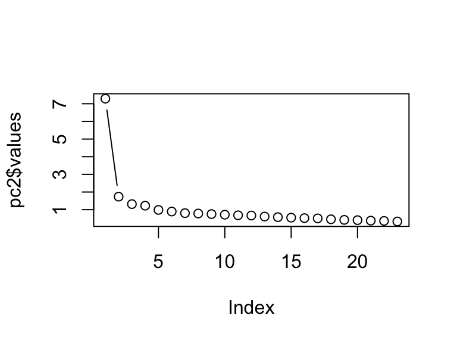

```r
plot(pc2$values, type = "b")
```

Explanation of ther result: Unchanged from the previous factor loading matrix except communalities (=h2 column) and uniquenesses (=u2 column) After extraction, some of the factors are discarded and so some information is lost.

```r
#Explore residuals
factor.model(pc2$loadings) #reproduce correlations, loadings: factor loading matrix
```

```
##          Q01       Q02     Q03      Q04      Q05      Q06      Q07
## Q01  0.43465 -0.111636 -0.3717  0.44716  0.37550  0.21761  0.36645
## Q02 -0.11164  0.413753  0.3799 -0.13355 -0.12228 -0.03344 -0.14793
## Q03 -0.37168  0.379940  0.5297 -0.39939 -0.34516 -0.20010 -0.37282
## Q04  0.44716 -0.133547 -0.3994  0.46859  0.39889  0.27808  0.41863
## Q05  0.37550 -0.122276 -0.3452  0.39889  0.34305  0.27299  0.38007
## Q06  0.21761 -0.033442 -0.2001  0.27808  0.27299  0.65393  0.52785
## Q07  0.36645 -0.147925 -0.3728  0.41863  0.38007  0.52785  0.54529
## Q08  0.41182  0.002192 -0.2697  0.39017  0.31226  0.18313  0.26730
## Q09 -0.04246  0.429520  0.3517 -0.07309 -0.07967 -0.10814 -0.16135
## Q10  0.17174 -0.061197 -0.1805  0.21245  0.20522  0.46139  0.38168
## Q11  0.42278 -0.097445 -0.3567  0.41918  0.34795  0.29044  0.36259
## Q12  0.40211 -0.218619 -0.4403  0.44771  0.39684  0.38806  0.49472
## Q13  0.34701 -0.121503 -0.3416  0.39539  0.35990  0.54453  0.53332
## Q14  0.36178 -0.155470 -0.3727  0.41055  0.37048  0.47748  0.51426
## Q15  0.31064 -0.157736 -0.3373  0.34299  0.30629  0.40647  0.42450
## Q16  0.43982 -0.217208 -0.4579  0.46574  0.39996  0.30028  0.43941
## Q17  0.43912 -0.048005 -0.3305  0.43433  0.35929  0.29016  0.36534
## Q18  0.36751 -0.148976 -0.3762  0.42444  0.38795  0.56151  0.56988
## Q19 -0.20401  0.356622  0.4027 -0.23108 -0.20668 -0.14669 -0.25448
## Q20  0.34188 -0.300644 -0.4399  0.35260  0.29208 -0.02060  0.21933
## Q21  0.44947 -0.253841 -0.4884  0.48013  0.41218  0.24359  0.43039
## Q22 -0.02541  0.333255  0.2746 -0.04968 -0.06033 -0.20858 -0.17861
## Q23  0.04463  0.246450  0.1582  0.04179  0.02794 -0.08173 -0.03719
##           Q08      Q09       Q10      Q11      Q12      Q13      Q14
## Q01  0.411819 -0.04246  0.171738  0.42278  0.40211  0.34701  0.36178
## Q02  0.002192  0.42952 -0.061197 -0.09745 -0.21862 -0.12150 -0.15547
## Q03 -0.269697  0.35173 -0.180532 -0.35673 -0.44032 -0.34159 -0.37266
## Q04  0.390165 -0.07309  0.212451  0.41918  0.44771  0.39539  0.41055
## Q05  0.312264 -0.07967  0.205218  0.34795  0.39684  0.35990  0.37048
## Q06  0.183133 -0.10814  0.461387  0.29044  0.38806  0.54453  0.47748
## Q07  0.267301 -0.16135  0.381682  0.36259  0.49472  0.53332  0.51426
## Q08  0.739464  0.05505  0.179642  0.69051  0.22848  0.31331  0.24880
## Q09  0.055050  0.48448 -0.116117 -0.07093 -0.19456 -0.14659 -0.15942
## Q10  0.179642 -0.11612  0.334773  0.25917  0.28341  0.39838  0.34545
## Q11  0.690505 -0.07093  0.259175  0.68960  0.31499  0.40272  0.33796
## Q12  0.228479 -0.19456  0.283414  0.31499  0.51333  0.45861  0.48101
## Q13  0.313307 -0.14659  0.398381  0.40272  0.45861  0.53583  0.49714
## Q14  0.248801 -0.15942  0.345445  0.33796  0.48101  0.49714  0.48826
## Q15  0.338623 -0.17446  0.313670  0.40991  0.37401  0.43315  0.39703
```

[output cut: 41 more lines]

```
## Q09  0.32317
## Q10 -0.11035
## Q11 -0.20226
## Q12  0.01064
## Q13 -0.07881
## Q14 -0.02161
## Q15 -0.14112
## Q16 -0.04930
## Q17 -0.14047
## Q18 -0.03160
## Q19  0.19557
## Q20  0.02125
## Q21  0.03196
## Q22  0.40772
## Q23  0.41219
```

```r
reproduced<-round(factor.model(pc2$loadings), 3) #format for book
reproduced[,1:9]  #format for book
```

```
##        Q01    Q02    Q03    Q04    Q05    Q06    Q07    Q08    Q09
## Q01  0.435 -0.112 -0.372  0.447  0.376  0.218  0.366  0.412 -0.042
## Q02 -0.112  0.414  0.380 -0.134 -0.122 -0.033 -0.148  0.002  0.430
## Q03 -0.372  0.380  0.530 -0.399 -0.345 -0.200 -0.373 -0.270  0.352
## Q04  0.447 -0.134 -0.399  0.469  0.399  0.278  0.419  0.390 -0.073
## Q05  0.376 -0.122 -0.345  0.399  0.343  0.273  0.380  0.312 -0.080
## Q06  0.218 -0.033 -0.200  0.278  0.273  0.654  0.528  0.183 -0.108
## Q07  0.366 -0.148 -0.373  0.419  0.380  0.528  0.545  0.267 -0.161
## Q08  0.412  0.002 -0.270  0.390  0.312  0.183  0.267  0.739  0.055
## Q09 -0.042  0.430  0.352 -0.073 -0.080 -0.108 -0.161  0.055  0.484
## Q10  0.172 -0.061 -0.181  0.212  0.205  0.461  0.382  0.180 -0.116
## Q11  0.423 -0.097 -0.357  0.419  0.348  0.290  0.363  0.691 -0.071
## Q12  0.402 -0.219 -0.440  0.448  0.397  0.388  0.495  0.228 -0.195
## Q13  0.347 -0.122 -0.342  0.395  0.360  0.545  0.533  0.313 -0.147
## Q14  0.362 -0.155 -0.373  0.411  0.370  0.477  0.514  0.249 -0.159
## Q15  0.311 -0.158 -0.337  0.343  0.306  0.406  0.425  0.339 -0.174
## Q16  0.440 -0.217 -0.458  0.466  0.400  0.300  0.439  0.390 -0.175
## Q17  0.439 -0.048 -0.331  0.434  0.359  0.290  0.365  0.695 -0.009
## Q18  0.368 -0.149 -0.376  0.424  0.388  0.562  0.570  0.250 -0.168
## Q19 -0.204  0.357  0.403 -0.231 -0.207 -0.147 -0.254 -0.104  0.363
## Q20  0.342 -0.301 -0.440  0.353  0.292 -0.021  0.219  0.164 -0.218
## Q21  0.449 -0.254 -0.488  0.480  0.412  0.244  0.430  0.282 -0.191
## Q22 -0.025  0.333  0.275 -0.050 -0.060 -0.209 -0.179 -0.099  0.417
## Q23  0.045  0.246  0.158  0.042  0.028 -0.082 -0.037 -0.136  0.323
```

```r
factor.residuals(raqMatrix, pc2$loadings) #residual: difference between the reproduced and actual correlation matrices
```

```
##            Q01       Q02       Q03        Q04       Q05        Q06
## Q01  0.5653523  0.012912  0.035030 -0.0113044  0.026937 -0.0008715
## Q02  0.0129120  0.586247 -0.061549  0.0216875  0.002930 -0.0407678
## Q03  0.0350305 -0.061549  0.470284  0.0189314  0.034852 -0.0266366
## Q04 -0.0113044  0.021687  0.018931  0.5314110  0.001785  0.0001197
## Q05  0.0269367  0.002930  0.034852  0.0017847  0.656950 -0.0155315
## Q06 -0.0008715 -0.040768 -0.026637  0.0001197 -0.015532  0.3460683
## Q07 -0.0610813 -0.011249 -0.009128 -0.0100145 -0.040680 -0.0142718
## Q08 -0.0810816 -0.051815  0.011063 -0.0407358 -0.043637  0.0396988
## Q09 -0.0498771 -0.114879 -0.051929 -0.0514555 -0.016028 -0.0045047
## Q10  0.0419437 -0.022806 -0.012856  0.0033595  0.052991 -0.1391567
## Q11 -0.0659930 -0.046385  0.006094 -0.0505189 -0.050126  0.0376298
## Q12 -0.0567251  0.023750  0.030364 -0.0060592 -0.050092 -0.0755501
## Q13  0.0076342 -0.021237  0.023673 -0.0511005 -0.058074 -0.0781221
## Q14 -0.0238980 -0.009229  0.001909 -0.0597378 -0.055139 -0.0752376
## Q15 -0.0648847 -0.007260  0.024943 -0.0087558 -0.044916 -0.0465812
## Q16  0.0588009  0.049656  0.039289 -0.0498741 -0.005045 -0.0559394
## Q17 -0.0685681 -0.038990  0.003147 -0.0515886 -0.048868 -0.0078958
## Q18 -0.0203929 -0.014918  0.000998 -0.0424390 -0.065860 -0.0481914
## Q19  0.0150009 -0.153325 -0.061137  0.0451025  0.041355 -0.0200595
## Q20 -0.1279836  0.099050  0.115017 -0.1096817 -0.092408  0.1215228
## Q21 -0.1203183  0.049224  0.071252 -0.0698336 -0.077569  0.0287461
## Q22 -0.0790016 -0.102380 -0.070949 -0.0487084 -0.072207  0.0434432
## Q23 -0.0491144 -0.146772 -0.008012 -0.0756083 -0.069598  0.0130409
##           Q07        Q08       Q09       Q10       Q11       Q12
## Q01 -0.061081 -0.0810816 -0.049877  0.041944 -0.065993 -0.056725
## Q02 -0.011249 -0.0518147 -0.114879 -0.022806 -0.046385  0.023750
## Q03 -0.009128  0.0110628 -0.051929 -0.012856  0.006094  0.030364
## Q04 -0.010015 -0.0407358 -0.051456  0.003359 -0.050519 -0.006059
## Q05 -0.040680 -0.0436374 -0.016028  0.052991 -0.050126 -0.050092
## Q06 -0.014272  0.0396988 -0.004505 -0.139157  0.037630 -0.075550
## Q07  0.454706  0.0301962  0.033051 -0.097959 -0.017846 -0.071733
## Q08  0.030196  0.2605365 -0.039317 -0.021034 -0.061208  0.023506
## Q09  0.033051 -0.0393171  0.515520 -0.018070 -0.044590  0.027165
## Q10 -0.097959 -0.0210338 -0.018070  0.665227  0.012262 -0.037588
## Q11 -0.017846 -0.0612075 -0.044590  0.012262  0.310395  0.020308
## Q12 -0.071733  0.0235064  0.027165 -0.037588  0.020308  0.486672
## Q13 -0.091202  0.0009401 -0.020847 -0.096414  0.020442  0.030102
## Q14 -0.073558  0.0317881  0.037914 -0.090758 -0.012641 -0.048309
## Q15 -0.033138 -0.0389370 -0.012113 -0.018436 -0.045083 -0.042214
```

[output cut: 41 more lines]

```
## Q09 -0.1139880  0.059655  0.054666 -0.160564 -0.152400
## Q10  0.0098525  0.078302  0.004732  0.065989  0.048436
## Q11 -0.0020650  0.055789  0.004747  0.047409  0.115883
## Q12  0.0357441 -0.056293 -0.062056 -0.030998 -0.057070
## Q13  0.0041344  0.040823 -0.009814  0.007402  0.025831
## Q14 -0.0002549 -0.015170 -0.031638 -0.010830 -0.026867
## Q15  0.0265823  0.030882 -0.035858  0.062231  0.079111
## Q16  0.0315941 -0.107530 -0.073630 -0.003588 -0.032222
## Q17 -0.0012349  0.009384  0.016011  0.019003  0.048801
## Q18  0.0028209  0.019847 -0.008653  0.023433 -0.048822
## Q19  0.6567577  0.059853  0.048819 -0.060136 -0.073134
## Q20  0.0598527  0.516004  0.010344 -0.031866 -0.055915
## Q21  0.0488185  0.010344  0.450093 -0.033126 -0.099620
## Q22 -0.0601359 -0.031866 -0.033126  0.536456 -0.177346
## Q23 -0.0731344 -0.055915 -0.099620 -0.177346  0.587809
```

```r
resids<-round(factor.residuals(raqMatrix, pc2$loadings), 3) #format for book
resids[,1:9] #format for book
```

```
##        Q01    Q02    Q03    Q04    Q05    Q06    Q07    Q08    Q09
## Q01  0.565  0.013  0.035 -0.011  0.027 -0.001 -0.061 -0.081 -0.050
## Q02  0.013  0.586 -0.062  0.022  0.003 -0.041 -0.011 -0.052 -0.115
## Q03  0.035 -0.062  0.470  0.019  0.035 -0.027 -0.009  0.011 -0.052
## Q04 -0.011  0.022  0.019  0.531  0.002  0.000 -0.010 -0.041 -0.051
## Q05  0.027  0.003  0.035  0.002  0.657 -0.016 -0.041 -0.044 -0.016
## Q06 -0.001 -0.041 -0.027  0.000 -0.016  0.346 -0.014  0.040 -0.005
## Q07 -0.061 -0.011 -0.009 -0.010 -0.041 -0.014  0.455  0.030  0.033
## Q08 -0.081 -0.052  0.011 -0.041 -0.044  0.040  0.030  0.261 -0.039
## Q09 -0.050 -0.115 -0.052 -0.051 -0.016 -0.005  0.033 -0.039  0.516
## Q10  0.042 -0.023 -0.013  0.003  0.053 -0.139 -0.098 -0.021 -0.018
## Q11 -0.066 -0.046  0.006 -0.051 -0.050  0.038 -0.018 -0.061 -0.045
## Q12 -0.057  0.024  0.030 -0.006 -0.050 -0.076 -0.072  0.024  0.027
## Q13  0.008 -0.021  0.024 -0.051 -0.058 -0.078 -0.091  0.001 -0.021
## Q14 -0.024 -0.009  0.002 -0.060 -0.055 -0.075 -0.074  0.032  0.038
## Q15 -0.065 -0.007  0.025 -0.009 -0.045 -0.047 -0.033 -0.039 -0.012
## Q16  0.059  0.050  0.039 -0.050 -0.005 -0.056 -0.051 -0.068 -0.014
## Q17 -0.069 -0.039  0.003 -0.052 -0.049 -0.008  0.025 -0.105 -0.027
## Q18 -0.020 -0.015  0.001 -0.042 -0.066 -0.048 -0.069  0.030  0.018
## Q19  0.015 -0.153 -0.061  0.045  0.041 -0.020 -0.015 -0.056 -0.114
## Q20 -0.128  0.099  0.115 -0.110 -0.092  0.122  0.002  0.011  0.060
## Q21 -0.120  0.049  0.071 -0.070 -0.078  0.029  0.053  0.014  0.055
## Q22 -0.079 -0.102 -0.071 -0.049 -0.072  0.043  0.010  0.020 -0.161
## Q23 -0.049 -0.147 -0.008 -0.076 -0.070  0.013 -0.033  0.086 -0.152
```

```r
pc2$fit.off #fit.off: how well are the off diagonal elements reproduced?
```

```
## [1] 0.9645
```

```r
residuals<-factor.residuals(raqMatrix, pc2$loadings)
residuals
```

```
##            Q01       Q02       Q03        Q04       Q05        Q06
## Q01  0.5653523  0.012912  0.035030 -0.0113044  0.026937 -0.0008715
## Q02  0.0129120  0.586247 -0.061549  0.0216875  0.002930 -0.0407678
## Q03  0.0350305 -0.061549  0.470284  0.0189314  0.034852 -0.0266366
## Q04 -0.0113044  0.021687  0.018931  0.5314110  0.001785  0.0001197
## Q05  0.0269367  0.002930  0.034852  0.0017847  0.656950 -0.0155315
## Q06 -0.0008715 -0.040768 -0.026637  0.0001197 -0.015532  0.3460683
## Q07 -0.0610813 -0.011249 -0.009128 -0.0100145 -0.040680 -0.0142718
## Q08 -0.0810816 -0.051815  0.011063 -0.0407358 -0.043637  0.0396988
## Q09 -0.0498771 -0.114879 -0.051929 -0.0514555 -0.016028 -0.0045047
## Q10  0.0419437 -0.022806 -0.012856  0.0033595  0.052991 -0.1391567
## Q11 -0.0659930 -0.046385  0.006094 -0.0505189 -0.050126  0.0376298
## Q12 -0.0567251  0.023750  0.030364 -0.0060592 -0.050092 -0.0755501
## Q13  0.0076342 -0.021237  0.023673 -0.0511005 -0.058074 -0.0781221
## Q14 -0.0238980 -0.009229  0.001909 -0.0597378 -0.055139 -0.0752376
## Q15 -0.0648847 -0.007260  0.024943 -0.0087558 -0.044916 -0.0465812
## Q16  0.0588009  0.049656  0.039289 -0.0498741 -0.005045 -0.0559394
## Q17 -0.0685681 -0.038990  0.003147 -0.0515886 -0.048868 -0.0078958
## Q18 -0.0203929 -0.014918  0.000998 -0.0424390 -0.065860 -0.0481914
## Q19  0.0150009 -0.153325 -0.061137  0.0451025  0.041355 -0.0200595
## Q20 -0.1279836  0.099050  0.115017 -0.1096817 -0.092408  0.1215228
## Q21 -0.1203183  0.049224  0.071252 -0.0698336 -0.077569  0.0287461
## Q22 -0.0790016 -0.102380 -0.070949 -0.0487084 -0.072207  0.0434432
## Q23 -0.0491144 -0.146772 -0.008012 -0.0756083 -0.069598  0.0130409
##           Q07        Q08       Q09       Q10       Q11       Q12
## Q01 -0.061081 -0.0810816 -0.049877  0.041944 -0.065993 -0.056725
## Q02 -0.011249 -0.0518147 -0.114879 -0.022806 -0.046385  0.023750
## Q03 -0.009128  0.0110628 -0.051929 -0.012856  0.006094  0.030364
## Q04 -0.010015 -0.0407358 -0.051456  0.003359 -0.050519 -0.006059
## Q05 -0.040680 -0.0436374 -0.016028  0.052991 -0.050126 -0.050092
## Q06 -0.014272  0.0396988 -0.004505 -0.139157  0.037630 -0.075550
## Q07  0.454706  0.0301962  0.033051 -0.097959 -0.017846 -0.071733
## Q08  0.030196  0.2605365 -0.039317 -0.021034 -0.061208  0.023506
## Q09  0.033051 -0.0393171  0.515520 -0.018070 -0.044590  0.027165
## Q10 -0.097959 -0.0210338 -0.018070  0.665227  0.012262 -0.037588
## Q11 -0.017846 -0.0612075 -0.044590  0.012262  0.310395  0.020308
## Q12 -0.071733  0.0235064  0.027165 -0.037588  0.020308  0.486672
## Q13 -0.091202  0.0009401 -0.020847 -0.096414  0.020442  0.030102
## Q14 -0.073558  0.0317881  0.037914 -0.090758 -0.012641 -0.048309
## Q15 -0.033138 -0.0389370 -0.012113 -0.018436 -0.045083 -0.042214
```

[output cut: 41 more lines]

```
## Q09 -0.1139880  0.059655  0.054666 -0.160564 -0.152400
## Q10  0.0098525  0.078302  0.004732  0.065989  0.048436
## Q11 -0.0020650  0.055789  0.004747  0.047409  0.115883
## Q12  0.0357441 -0.056293 -0.062056 -0.030998 -0.057070
## Q13  0.0041344  0.040823 -0.009814  0.007402  0.025831
## Q14 -0.0002549 -0.015170 -0.031638 -0.010830 -0.026867
## Q15  0.0265823  0.030882 -0.035858  0.062231  0.079111
## Q16  0.0315941 -0.107530 -0.073630 -0.003588 -0.032222
## Q17 -0.0012349  0.009384  0.016011  0.019003  0.048801
## Q18  0.0028209  0.019847 -0.008653  0.023433 -0.048822
## Q19  0.6567577  0.059853  0.048819 -0.060136 -0.073134
## Q20  0.0598527  0.516004  0.010344 -0.031866 -0.055915
## Q21  0.0488185  0.010344  0.450093 -0.033126 -0.099620
## Q22 -0.0601359 -0.031866 -0.033126  0.536456 -0.177346
## Q23 -0.0731344 -0.055915 -0.099620 -0.177346  0.587809
```

```r
residuals<-as.matrix(residuals[upper.tri(residuals)])
#upper.tri(): Extracting only the elements above the diagonal (so we discard the diagonal elements and the elements below the diagonal)
#as.matrix(): Makes sure that the residuals are stored as a matrix
```

```r
large.resid<-abs(residuals) > 0.05 #How many large residuals there are
sum(large.resid)
```

```
## [1] 91
```

```r
sum(large.resid)/nrow(residuals) #If more than 50% > 0.05 for concern. 36% => do not worry
```

```
## [1] 0.3597
```

```r
sqrt(mean(residuals^2))
```

```
## [1] 0.05549
```

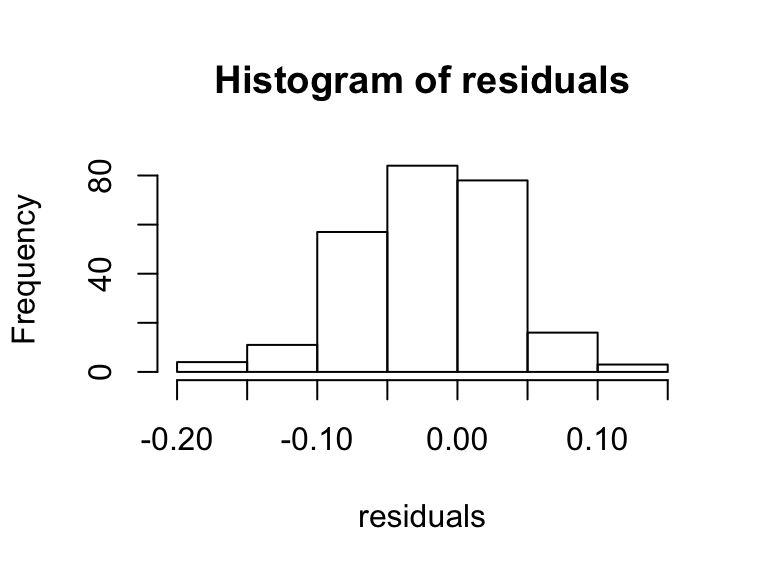

```r
hist(residuals) #Approximately normal, no outliers
```

Extract the residuals from the matrix entered into the function. compute the number and proportion of absolute values > 0.05 and the root mean squared residual and plot a histogram.

```r
residual.stats<-function(matrix){
    residuals<-as.matrix(matrix[upper.tri(matrix)])
    large.resid<-abs(residuals) > 0.05
    numberLargeResids<-sum(large.resid)
    propLargeResid<-numberLargeResids/nrow(residuals)
    rmsr<-sqrt(mean(residuals^2))

    cat("Root means squared residual = ", rmsr, "\n")
    cat("Number of absolute residuals > 0.05 = ", numberLargeResids, "\n")
    cat("Proportion of absolute residuals > 0.05 = ", propLargeResid, "\n")
    hist(residuals)
}
```

Calculate residual matrix

```r
resids <- factor.residuals(raqMatrix, pc2$loadings )
residual.stats(resids)
```

```
## Root means squared residual =  0.05549
## Number of absolute residuals > 0.05 =  91
## Proportion of absolute residuals > 0.05 =  0.3597
```

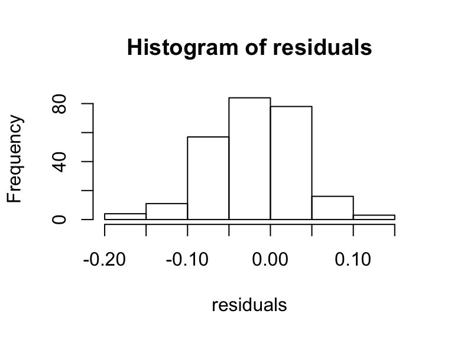

```r
#residual.stats(factor.residuals(raqMatrix, pc2$loadings))
```

**Factor rotation**

```r
pc3 <-  principal(raqData, nfactors = 4, rotate = "varimax")
```

Loadings and eigenvalues (55 loadings) have changed, but the h2 (communality) and (uniqueness) columns have not.

```r
print.psych(pc3, cut = 0.3, sort = TRUE)
```

```
## Principal Components Analysis
## Call: principal(r = raqData, nfactors = 4, rotate = "varimax")
## Standardized loadings (pattern matrix) based upon correlation matrix
##     item   RC3   RC1   RC4   RC2   h2   u2
## Q06    6  0.80                   0.65 0.35
## Q18   18  0.68  0.33             0.60 0.40
## Q13   13  0.65                   0.54 0.46
## Q07    7  0.64  0.33             0.55 0.45
## Q14   14  0.58  0.36             0.49 0.51
## Q10   10  0.55                   0.33 0.67
## Q15   15  0.46                   0.38 0.62
## Q20   20        0.68             0.48 0.52
## Q21   21        0.66             0.55 0.45
## Q03    3       -0.57        0.37 0.53 0.47
## Q12   12  0.47  0.52             0.51 0.49
## Q04    4  0.32  0.52  0.31       0.47 0.53
## Q16   16  0.33  0.51  0.31       0.49 0.51
## Q01    1        0.50  0.36       0.43 0.57
## Q05    5  0.32  0.43             0.34 0.66
## Q08    8              0.83       0.74 0.26
## Q17   17              0.75       0.68 0.32
## Q11   11              0.75       0.69 0.31
## Q09    9                    0.65 0.48 0.52
## Q22   22                    0.65 0.46 0.54
## Q23   23                    0.59 0.41 0.59
## Q02    2       -0.34        0.54 0.41 0.59
## Q19   19       -0.37        0.43 0.34 0.66
##
##                        RC3  RC1  RC4  RC2
## SS loadings           3.73 3.34 2.55 1.95
## Proportion Var        0.16 0.15 0.11 0.08
## Cumulative Var        0.16 0.31 0.42 0.50
## Proportion Explained  0.32 0.29 0.22 0.17
## Cumulative Proportion 0.32 0.61 0.83 1.00
##
## Test of the hypothesis that 4 components are sufficient.
##
## The degrees of freedom for the null model are  253  and the objective function was  7.55
## The degrees of freedom for the model are 167  and the objective function was  1.03
## The total number of observations was  2571  with MLE Chi Square =  2634  with prob <  0
##
## Fit based upon off diagonal values = 0.96
```

print.psych: 1)removes loadings that are below a certain value 2)reorders the items to try to put them into their factors (using sort option). cut = 0.3: use a lower cut-off(0.3) than you are interested(0.4) => don’t miss a loading .39 sort =TRUE: sorting items by the size of their loadings

Before rotation, most variables loaded highly on the first factor and the remaining factors didn’t really get a look in. After rotation: there are four factors and variables load very highly onto only one factor (with the exception of one question). The suppression of loadings less than .3 and ordering variables by loading size also make interpretation considerably easier

```r
pc4 <- principal(raqData, nfactors = 4, rotate = "oblimin")
print.psych(pc4, cut = 0.3, sort = TRUE)
```

```
## Principal Components Analysis
## Call: principal(r = raqData, nfactors = 4, rotate = "oblimin")
## Standardized loadings (pattern matrix) based upon correlation matrix
##     item   TC1   TC4   TC3   TC2   h2   u2
## Q06    6  0.87                   0.65 0.35
## Q18   18  0.70                   0.60 0.40
## Q07    7  0.64                   0.55 0.45
## Q13   13  0.64                   0.54 0.46
## Q10   10  0.57                   0.33 0.67
## Q14   14  0.57                   0.49 0.51
## Q12   12  0.45        0.43       0.51 0.49
## Q15   15  0.40                   0.38 0.62
## Q08    8        0.90             0.74 0.26
## Q11   11        0.78             0.69 0.31
## Q17   17        0.78             0.68 0.32
## Q20   20              0.71       0.48 0.52
## Q21   21              0.60       0.55 0.45
## Q03    3             -0.51       0.53 0.47
## Q04    4              0.41       0.47 0.53
## Q16   16              0.41       0.49 0.51
## Q01    1        0.33  0.40       0.43 0.57
## Q05    5              0.34       0.34 0.66
## Q22   22                    0.65 0.46 0.54
## Q09    9                    0.63 0.48 0.52
## Q23   23                    0.61 0.41 0.59
## Q02    2             -0.36  0.51 0.41 0.59
## Q19   19             -0.35  0.38 0.34 0.66
##
##                        TC1  TC4  TC3  TC2
## SS loadings           3.90 2.88 2.94 1.85
## Proportion Var        0.17 0.13 0.13 0.08
## Cumulative Var        0.17 0.29 0.42 0.50
## Proportion Explained  0.34 0.25 0.25 0.16
## Cumulative Proportion 0.34 0.59 0.84 1.00
##
##  With component correlations of
##       TC1   TC4   TC3   TC2
## TC1  1.00  0.44  0.36 -0.18
## TC4  0.44  1.00  0.31 -0.10
## TC3  0.36  0.31  1.00 -0.17
## TC2 -0.18 -0.10 -0.17  1.00
##
## Test of the hypothesis that 4 components are sufficient.
##
## The degrees of freedom for the null model are  253  and the objective function was  7.55
## The degrees of freedom for the model are 167  and the objective function was  1.03
## The total number of observations was  2571  with MLE Chi Square =  2634  with prob <  0
##
## Fit based upon off diagonal values = 0.96
```

Final matrix gives us a guide to whether it is reasonable to assume independence between factors. we cannot assume independence. => unstrusted orthogonal rotation! more meaningful oblique rotation!

Pattern matrix contains the factor loadings and is comparable to the factor matrix for orthogonal rotation. more simple! Structure matrix considers the relationship between factors (in fact it is a product of the pattern matrix and the matrix containing the correlation coefficients between factors). useful double-check! => different in oblique rotation, same in orthogonal rotation

Calculate structure matrix: multiply the factor loading matrix by the correlation matrix of the factors.

```r
pc4$loadings%*%pc4$Phi
```

```
##          TC1      TC4      TC3      TC2
## Q01  0.39880  0.50177  0.53086  0.01320
## Q02 -0.12176 -0.03711 -0.39341  0.55185
## Q03 -0.38833 -0.36191 -0.63587  0.40844
## Q04  0.47399  0.48673  0.55954 -0.01519
## Q05  0.44295  0.39706  0.47208 -0.03392
## Q06  0.78264  0.28840  0.09677 -0.14284
## Q07  0.71840  0.37906  0.41522 -0.15228
## Q08  0.29889  0.85442  0.23113 -0.03146
## Q09 -0.17581  0.01280 -0.28137  0.65806
## Q10  0.55726  0.26323  0.08698 -0.17303
## Q11  0.43276  0.82077  0.29601 -0.18925
## Q12  0.59712  0.32534  0.58523 -0.14640
## Q13  0.71860  0.43004  0.33087 -0.16982
## Q14  0.66538  0.35293  0.43812 -0.13978
## Q15  0.55285  0.44440  0.30665 -0.24116
## Q16  0.50041  0.49590  0.57769 -0.17046
## Q17  0.43614  0.82189  0.30094 -0.08993
## Q18  0.75722  0.36374  0.41837 -0.15366
## Q19 -0.26952 -0.16545 -0.43533  0.45257
## Q20  0.14628  0.21018  0.68271 -0.16379
## Q21  0.46173  0.37118  0.70197 -0.12620
## Q22 -0.24703 -0.16320 -0.07153  0.65970
## Q23 -0.06588 -0.18188  0.08484  0.58293
```

```r
factor.structure <- function(fa, cut = 0.2, decimals = 2){
    structure.matrix <- fa.sort(fa$loadings %*% fa$Phi)
    structure.matrix <- data.frame(ifelse(abs(structure.matrix) < cut, "", round(structure.matrix, decimals)))
    return(structure.matrix)
    }

factor.structure(pc4, cut = 0.3) #in DSUR package
```

```
##       TC1   TC4   TC3  TC2
## Q06  0.78
## Q18  0.76  0.36  0.42
## Q13  0.72  0.43  0.33
## Q07  0.72  0.38  0.42
## Q14  0.67  0.35  0.44
## Q12   0.6  0.33  0.59
## Q10  0.56
## Q15  0.55  0.44  0.31
## Q08        0.85
## Q17  0.44  0.82   0.3
## Q11  0.43  0.82
## Q21  0.46  0.37   0.7
## Q20              0.68
## Q03 -0.39 -0.36 -0.64 0.41
## Q16   0.5   0.5  0.58
## Q04  0.47  0.49  0.56
## Q01   0.4   0.5  0.53
## Q05  0.44   0.4  0.47
## Q22                   0.66
## Q09                   0.66
## Q23                   0.58
## Q02             -0.39 0.55
## Q19             -0.44 0.45
```

pattern matrix is preferable for interpretative reasons because it contains information about the contribution of a variable to a factor. conclusion: expect a fairly strong relationship between fear of maths, fear of statistics and fear of computers.

Factor scores : used to assess the relative fear of one person compared to another.

```r
pc5 <- principal(raqData, nfactors = 4, rotate = "oblimin", scores = TRUE) #scores = TRUE : calculation for factor score
pc5$scores
```

```
##                TC1        TC4        TC3       TC2
##    [1,]  0.3729671  1.8808424  0.9597960  0.391071
##    [2,]  0.6333416  0.2374679  0.2909078 -0.350408
##    [3,]  0.3971277 -0.1056263 -0.0933377  0.924935
##    [4,] -0.7874159  0.2956628 -0.7770331  0.260567
##    [5,]  0.0442594  0.6815179  0.5978661 -0.691269
##    [6,] -1.7001865  0.2091685  0.0278416  0.665308
##    [7,]  0.6613924  0.4224096  1.5255202 -0.980543
##    [8,]  0.5949133  0.4060248  1.0646596 -1.093260
##    [9,] -2.3497119 -3.6134797 -1.4299947 -0.544377
##   [10,]  0.9350460  0.2285419  0.9673573 -1.571275
##   [11,]  1.2862310  1.0680799  0.8474694 -2.407917
##   [12,]  0.1006076  0.8671797 -0.3498179 -0.637324
##   [13,] -0.8713208 -0.9146963 -0.9552942 -0.014760
##   [14,] -0.5193032  0.3026455 -1.0418370  1.446806
```

[output cut: 2557 more lines]

```r
head(pc5$scores, 10)
```

```
##            TC1     TC4      TC3     TC2
##  [1,]  0.37297  1.8808  0.95980  0.3911
##  [2,]  0.63334  0.2375  0.29091 -0.3504
##  [3,]  0.39713 -0.1056 -0.09334  0.9249
##  [4,] -0.78742  0.2957 -0.77703  0.2606
##  [5,]  0.04426  0.6815  0.59787 -0.6913
##  [6,] -1.70019  0.2092  0.02784  0.6653
##  [7,]  0.66139  0.4224  1.52552 -0.9805
##  [8,]  0.59491  0.4060  1.06466 -1.0933
##  [9,] -2.34971 -3.6135 -1.42999 -0.5444
## [10,]  0.93505  0.2285  0.96736 -1.5713
```

```r
raqData <- cbind(raqData, pc5$scores) #cbind: add the factor scores into our dataframe
```

```r
cor(pc5$scores)
```

```
##         TC1      TC4     TC3      TC2
## TC1  1.0000  0.44300  0.3621 -0.18337
## TC4  0.4430  1.00000  0.3099 -0.09733
## TC3  0.3621  0.30985  1.0000 -0.16573
## TC2 -0.1834 -0.09733 -0.1657  1.00000
```

```r
round(cor(pc5$scores), 2)
```

```
##       TC1   TC4   TC3   TC2
## TC1  1.00  0.44  0.36 -0.18
## TC4  0.44  1.00  0.31 -0.10
## TC3  0.36  0.31  1.00 -0.17
## TC2 -0.18 -0.10 -0.17  1.00
```

```r
#self test
round(cor(pc5$scores, raqData$Q01),2)
```

```
##     [,1]
## TC1 0.40
## TC4 0.50
## TC3 0.53
## TC2 0.01
```

```r
round(cor(pc5$scores, raqData$Q06),2)
```

```
##      [,1]
## TC1  0.78
## TC4  0.29
## TC3  0.10
## TC2 -0.14
```

```r
round(cor(pc5$scores, raqData$Q18),2)
```

```
##      [,1]
## TC1  0.76
## TC4  0.36
## TC3  0.42
## TC2 -0.15
```

```r
#On an R matrix
#pc1 <- principal(raqMatrix, nfactors = 23, rotate = "none")
pc1 <- principal(raqMatrix, nfactors = length(raqMatrix[,1]), rotate = "none")
pc2 <- principal(raqMatrix, nfactors = 4, rotate = "none")
pc3 <- principal(raqMatrix, nfactors = 4, rotate = "varimax")
pc4 <- principal(raqMatrix, nfactors = 4, residuals = TRUE, rotate = "oblimin")
pc5 <- principal(raqMatrix, nfactors = 4, rotate = "oblimin", scores = TRUE)
```

#### Reliability analysis

```r
computerFear<-raqData[,c(6, 7, 10, 13, 14, 15, 18)]
statisticsFear <- raqData[, c(1, 3, 4, 5, 12, 16, 20, 21)]
mathFear <- raqData[, c(8, 11, 17)]
peerEvaluation <- raqData[, c(2, 9, 19, 22, 23)]
```

Interpretation of the result:

number of item dependant, alpha>0.8=:good reliablity raw_alpha: values of the overall G6 if the item is removed

Item statistics-r(=item-total correlations): correlations between each item and the total score from the questionnaire.

Item statistics-r.drop(=item-rest correlation,corrected item-total correlation): correlation of that item with the scale total if that item isn’t included in the scale total. r.drop <~ .3 => problems and shold be removed! a particular item does not correlate very well with the scale overall.

Final part of table: percentage of people gave each response to each of the items

```r
alpha(computerFear)
```

```
##
## Reliability analysis
## Call: alpha(x = computerFear)
##
##   raw_alpha std.alpha G6(smc) average_r S/N    ase mean   sd
##       0.82      0.82    0.81       0.4 4.6 0.0094  3.4 0.71
##
##  lower alpha upper     95% confidence boundaries
## 0.8 0.82 0.84
##
##  Reliability if an item is dropped:
##     raw_alpha std.alpha G6(smc) average_r S/N alpha se
## Q06      0.79      0.79    0.77      0.38 3.7    0.011
## Q07      0.79      0.79    0.77      0.38 3.7    0.011
## Q10      0.82      0.82    0.80      0.44 4.7    0.010
## Q13      0.79      0.79    0.77      0.39 3.8    0.011
## Q14      0.80      0.80    0.77      0.39 3.9    0.011
## Q15      0.81      0.81    0.79      0.41 4.2    0.011
## Q18      0.79      0.78    0.76      0.38 3.6    0.011
##
##  Item statistics
##        n    r r.cor r.drop mean   sd
## Q06 2571 0.74  0.68   0.62  3.8 1.12
## Q07 2571 0.73  0.68   0.62  3.1 1.10
## Q10 2571 0.57  0.44   0.40  3.7 0.88
## Q13 2571 0.73  0.67   0.61  3.6 0.95
## Q14 2571 0.70  0.64   0.58  3.1 1.00
## Q15 2571 0.64  0.54   0.49  3.2 1.01
## Q18 2571 0.76  0.72   0.65  3.4 1.05
##
## Non missing response frequency for each item
##        1    2    3    4    5 miss
## Q06 0.06 0.10 0.13 0.44 0.27    0
## Q07 0.09 0.24 0.26 0.34 0.07    0
## Q10 0.02 0.10 0.18 0.57 0.14    0
## Q13 0.03 0.12 0.25 0.48 0.12    0
## Q14 0.07 0.18 0.38 0.31 0.06    0
## Q15 0.06 0.18 0.30 0.39 0.07    0
## Q18 0.06 0.12 0.31 0.37 0.14    0
```

```r
alpha(statisticsFear, keys = c(1, -1, 1, 1, 1, 1, 1, 1)) # keys option => variable in the data set is nagative!
```

```
##
## Reliability analysis
## Call: alpha(x = statisticsFear, keys = c(1, -1, 1, 1, 1, 1, 1, 1))
##
##   raw_alpha std.alpha G6(smc) average_r S/N    ase mean   sd
##       0.82      0.82    0.81      0.37 4.7 0.0089    3 0.64
##
##  lower alpha upper     95% confidence boundaries
## 0.8 0.82 0.84
##
##  Reliability if an item is dropped:
##      raw_alpha std.alpha G6(smc) average_r S/N alpha se
## Q01       0.80      0.80    0.79      0.37 4.1   0.0101
## Q03-      0.80      0.80    0.79      0.37 4.1   0.0101
## Q04       0.80      0.80    0.78      0.36 4.0   0.0102
## Q05       0.81      0.81    0.80      0.38 4.2   0.0099
## Q12       0.80      0.80    0.79      0.36 4.0   0.0102
## Q16       0.79      0.80    0.78      0.36 3.9   0.0103
## Q20       0.82      0.82    0.80      0.40 4.6   0.0096
## Q21       0.79      0.80    0.78      0.36 3.9   0.0104
##
##  Item statistics
##         n    r r.cor r.drop mean   sd
## Q01  2571 0.67  0.60   0.54  3.6 0.83
## Q03- 2571 0.67  0.60   0.55  2.6 1.08
## Q04  2571 0.70  0.64   0.58  3.2 0.95
## Q05  2571 0.63  0.55   0.49  3.3 0.96
## Q12  2571 0.69  0.63   0.57  2.8 0.92
## Q16  2571 0.71  0.67   0.60  3.1 0.92
## Q20  2571 0.56  0.47   0.42  2.4 1.04
## Q21  2571 0.71  0.67   0.61  2.8 0.98
##
## Non missing response frequency for each item
##        1    2    3    4    5 miss
## Q01 0.02 0.07 0.29 0.52 0.11    0
## Q03 0.03 0.17 0.34 0.26 0.19    0
## Q04 0.05 0.17 0.36 0.37 0.05    0
## Q05 0.04 0.18 0.29 0.43 0.06    0
## Q12 0.09 0.23 0.46 0.20 0.02    0
## Q16 0.06 0.16 0.42 0.33 0.04    0
## Q20 0.22 0.37 0.25 0.15 0.02    0
## Q21 0.09 0.29 0.34 0.26 0.02    0
```

```r
alpha(mathFear)
```

```
##
## Reliability analysis
## Call: alpha(x = mathFear)
##
##   raw_alpha std.alpha G6(smc) average_r S/N   ase mean   sd
##       0.82      0.82    0.75       0.6 4.5 0.017  3.7 0.75
##
##  lower alpha upper     95% confidence boundaries
## 0.79 0.82 0.85
##
##  Reliability if an item is dropped:
##     raw_alpha std.alpha G6(smc) average_r S/N alpha se
## Q08      0.74      0.74    0.59      0.59 2.8    0.028
## Q11      0.74      0.74    0.59      0.59 2.9    0.028
## Q17      0.77      0.77    0.63      0.63 3.4    0.027
##
##  Item statistics
##        n    r r.cor r.drop mean   sd
## Q08 2571 0.86  0.76   0.68  3.8 0.87
## Q11 2571 0.86  0.75   0.68  3.7 0.88
## Q17 2571 0.85  0.72   0.65  3.5 0.88
##
## Non missing response frequency for each item
##        1    2    3    4    5 miss
## Q08 0.03 0.06 0.19 0.58 0.15    0
## Q11 0.02 0.06 0.22 0.53 0.16    0
## Q17 0.03 0.10 0.27 0.52 0.08    0
```

```r
alpha(peerEvaluation)
```

```
##
## Reliability analysis
## Call: alpha(x = peerEvaluation)
##
##   raw_alpha std.alpha G6(smc) average_r S/N   ase mean   sd
##       0.57      0.57    0.53      0.21 1.3 0.018  3.4 0.65
##
##  lower alpha upper     95% confidence boundaries
## 0.53 0.57 0.61
##
##  Reliability if an item is dropped:
##     raw_alpha std.alpha G6(smc) average_r  S/N alpha se
## Q02      0.52      0.52    0.45      0.21 1.07    0.022
## Q09      0.48      0.48    0.41      0.19 0.92    0.023
## Q19      0.52      0.53    0.46      0.22 1.11    0.021
## Q22      0.49      0.49    0.43      0.19 0.96    0.022
## Q23      0.56      0.57    0.50      0.25 1.32    0.020
##
##  Item statistics
##        n    r r.cor r.drop mean   sd
## Q02 2571 0.61  0.45   0.34  4.4 0.85
## Q09 2571 0.66  0.53   0.39  3.2 1.26
## Q19 2571 0.60  0.42   0.32  3.7 1.10
## Q22 2571 0.64  0.50   0.38  3.1 1.04
## Q23 2571 0.53  0.31   0.24  2.6 1.04
##
## Non missing response frequency for each item
##        1    2    3    4    5 miss
## Q02 0.01 0.04 0.08 0.31 0.56    0
## Q09 0.08 0.28 0.23 0.20 0.20    0
## Q19 0.02 0.15 0.22 0.33 0.29    0
## Q22 0.05 0.26 0.34 0.26 0.10    0
## Q23 0.12 0.42 0.27 0.12 0.06    0
```

```r
alpha(statisticsFear) #for illustrative pruposes
```

```
##
## Reliability analysis
## Call: alpha(x = statisticsFear)
##
##   raw_alpha std.alpha G6(smc) average_r S/N    ase mean   sd
##       0.82      0.82    0.81      0.37 4.7 0.0089    3 0.64
##
##  lower alpha upper     95% confidence boundaries
## 0.8 0.82 0.84
##
##  Reliability if an item is dropped:
##      raw_alpha std.alpha G6(smc) average_r S/N alpha se
## Q01       0.80      0.80    0.79      0.37 4.1   0.0101
## Q03-      0.80      0.80    0.79      0.37 4.1   0.0101
## Q04       0.80      0.80    0.78      0.36 4.0   0.0102
## Q05       0.81      0.81    0.80      0.38 4.2   0.0099
## Q12       0.80      0.80    0.79      0.36 4.0   0.0102
## Q16       0.79      0.80    0.78      0.36 3.9   0.0103
## Q20       0.82      0.82    0.80      0.40 4.6   0.0096
## Q21       0.79      0.80    0.78      0.36 3.9   0.0104
##
##  Item statistics
##         n    r r.cor r.drop mean   sd
## Q01  2571 0.67  0.60   0.54  3.6 0.83
## Q03- 2571 0.67  0.60   0.55  2.6 1.08
## Q04  2571 0.70  0.64   0.58  3.2 0.95
## Q05  2571 0.63  0.55   0.49  3.3 0.96
## Q12  2571 0.69  0.63   0.57  2.8 0.92
## Q16  2571 0.71  0.67   0.60  3.1 0.92
## Q20  2571 0.56  0.47   0.42  2.4 1.04
## Q21  2571 0.71  0.67   0.61  2.8 0.98
##
## Non missing response frequency for each item
##        1    2    3    4    5 miss
## Q01 0.02 0.07 0.29 0.52 0.11    0
## Q03 0.03 0.17 0.34 0.26 0.19    0
## Q04 0.05 0.17 0.36 0.37 0.05    0
## Q05 0.04 0.18 0.29 0.43 0.06    0
## Q12 0.09 0.23 0.46 0.20 0.02    0
## Q16 0.06 0.16 0.42 0.33 0.04    0
## Q20 0.22 0.37 0.25 0.15 0.02    0
## Q21 0.09 0.29 0.34 0.26 0.02    0
```

If the deletion of an item increases Cronbach’s then this means that the deletion of that item improves reliability. => Any items that have values of a in this column greater than the overall a may need to be deleted from the scale to improve its reliability.

### Labcoat Leni (Internet addiction Example)

```r
#load data (p797. Internet addiction research)
setwd("~/Documents/Study/DSUR/aall_data_files")
internetData<-read.delim("Nichols & Nicki (2004).dat", header = TRUE)
```

```r
#Create a correlation matrix
internetMatrix<-cor(internetData)
round(internetMatrix, 2)
```

```
##       ias1 ias2 ias3 ias4 ias5 ias6 ias7 ias8 ias9 ias10 ias11 ias12 ias13
## ias1  1.00 0.43 0.46 0.35 0.52 0.56 0.48 0.48 0.51  0.43  0.42  0.43  0.12
## ias2  0.43 1.00 0.33 0.54 0.38 0.24 0.39 0.32 0.29  0.30  0.26  0.32  0.37
## ias3  0.46 0.33 1.00 0.52 0.47 0.41 0.49 0.62 0.50  0.40  0.43  0.46  0.19
## ias4  0.35 0.54 0.52 1.00 0.46 0.27 0.45 0.44 0.37  0.37  0.27  0.44  0.31
## ias5  0.52 0.38 0.47 0.46 1.00 0.48 0.43 0.59 0.51  0.52  0.34  0.44  0.24
## ias6  0.56 0.24 0.41 0.27 0.48 1.00 0.50 0.43 0.50  0.59  0.42  0.50  0.10
## ias7  0.48 0.39 0.49 0.45 0.43 0.50 1.00 0.47 0.54  0.60  0.41  0.60  0.22
## ias8  0.48 0.32 0.62 0.44 0.59 0.43 0.47 1.00 0.63  0.48  0.43  0.54  0.24
## ias9  0.51 0.29 0.50 0.37 0.51 0.50 0.54 0.63 1.00  0.56  0.44  0.49  0.21
## ias10 0.43 0.30 0.40 0.37 0.52 0.59 0.60 0.48 0.56  1.00  0.51  0.64  0.21
## ias11 0.42 0.26 0.43 0.27 0.34 0.42 0.41 0.43 0.44  0.51  1.00  0.51  0.23
## ias12 0.43 0.32 0.46 0.44 0.44 0.50 0.60 0.54 0.49  0.64  0.51  1.00  0.26
## ias13 0.12 0.37 0.19 0.31 0.24 0.10 0.22 0.24 0.21  0.21  0.23  0.26  1.00
## ias14 0.49 0.38 0.40 0.36 0.40 0.44 0.37 0.42 0.45  0.49  0.42  0.43  0.19
## ias15 0.51 0.35 0.42 0.27 0.37 0.39 0.36 0.42 0.45  0.44  0.55  0.38  0.11
## ias16 0.52 0.30 0.40 0.31 0.36 0.39 0.27 0.42 0.34  0.25  0.40  0.27  0.10
## ias17 0.35 0.25 0.39 0.29 0.40 0.50 0.50 0.43 0.50  0.57  0.46  0.60  0.12
## ias18 0.47 0.28 0.36 0.34 0.47 0.39 0.55 0.46 0.54  0.58  0.46  0.50  0.16
## ias19 0.46 0.28 0.65 0.42 0.51 0.49 0.44 0.63 0.48  0.49  0.49  0.54  0.16
## ias20 0.48 0.29 0.44 0.42 0.47 0.45 0.53 0.53 0.52  0.56  0.46  0.55  0.19
## ias21 0.47 0.29 0.45 0.36 0.52 0.49 0.55 0.57 0.63  0.58  0.54  0.61  0.27
## ias22 0.16 0.15 0.18 0.15 0.15 0.16 0.15 0.29 0.10  0.22  0.33  0.22  0.31
## ias23 0.28 0.19 0.26 0.25 0.34 0.29 0.21 0.30 0.32  0.30  0.31  0.25  0.20
## ias24 0.42 0.31 0.60 0.41 0.49 0.38 0.49 0.54 0.51  0.45  0.53  0.49  0.33
## ias25 0.45 0.26 0.35 0.37 0.47 0.36 0.39 0.51 0.41  0.40  0.42  0.43  0.20
## ias26 0.52 0.28 0.44 0.27 0.43 0.65 0.44 0.47 0.46  0.51  0.57  0.53  0.14
## ias27 0.40 0.29 0.39 0.26 0.35 0.33 0.37 0.40 0.34  0.28  0.36  0.27  0.18
## ias28 0.49 0.20 0.37 0.22 0.39 0.57 0.42 0.49 0.50  0.48  0.58  0.47  0.19
## ias29 0.54 0.32 0.40 0.43 0.55 0.46 0.48 0.45 0.51  0.58  0.45  0.53  0.19
## ias30 0.47 0.30 0.42 0.39 0.47 0.42 0.41 0.43 0.41  0.38  0.36  0.43  0.21
## ias31 0.33 0.24 0.51 0.28 0.33 0.28 0.33 0.39 0.30  0.30  0.30  0.34  0.17
## ias32 0.22 0.15 0.26 0.17 0.25 0.36 0.14 0.23 0.13  0.27  0.19  0.22  0.26
## ias33 0.50 0.36 0.45 0.47 0.60 0.35 0.50 0.49 0.53  0.47  0.44  0.46  0.23
## ias34 0.44 0.20 0.29 0.22 0.42 0.47 0.43 0.41 0.37  0.52  0.34  0.37  0.10
## ias35 0.38 0.27 0.43 0.25 0.42 0.26 0.25 0.47 0.25  0.27  0.31  0.25  0.16
## ias36 0.49 0.32 0.46 0.35 0.47 0.51 0.66 0.56 0.55  0.64  0.49  0.56  0.20
##       ias14 ias15 ias16 ias17 ias18 ias19 ias20 ias21 ias22 ias23 ias24
## ias1   0.49  0.51  0.52  0.35  0.47  0.46  0.48  0.47  0.16  0.28  0.42
## ias2   0.38  0.35  0.30  0.25  0.28  0.28  0.29  0.29  0.15  0.19  0.31
```

[output cut: 93 more lines]

```
## ias22  0.27
## ias23  0.47
## ias24  0.49
## ias25  0.51
## ias26  0.64
## ias27  0.35
## ias28  0.65
## ias29  0.64
## ias30  0.49
## ias31  0.35
## ias32  0.19
## ias33  0.52
## ias34  0.58
## ias35  0.43
## ias36  1.00
```

```r
#Break down the matrix to make it easier to put in the book
round(internetMatrix[,1:12], 2)
```

```
##       ias1 ias2 ias3 ias4 ias5 ias6 ias7 ias8 ias9 ias10 ias11 ias12
## ias1  1.00 0.43 0.46 0.35 0.52 0.56 0.48 0.48 0.51  0.43  0.42  0.43
## ias2  0.43 1.00 0.33 0.54 0.38 0.24 0.39 0.32 0.29  0.30  0.26  0.32
## ias3  0.46 0.33 1.00 0.52 0.47 0.41 0.49 0.62 0.50  0.40  0.43  0.46
## ias4  0.35 0.54 0.52 1.00 0.46 0.27 0.45 0.44 0.37  0.37  0.27  0.44
## ias5  0.52 0.38 0.47 0.46 1.00 0.48 0.43 0.59 0.51  0.52  0.34  0.44
## ias6  0.56 0.24 0.41 0.27 0.48 1.00 0.50 0.43 0.50  0.59  0.42  0.50
## ias7  0.48 0.39 0.49 0.45 0.43 0.50 1.00 0.47 0.54  0.60  0.41  0.60
## ias8  0.48 0.32 0.62 0.44 0.59 0.43 0.47 1.00 0.63  0.48  0.43  0.54
## ias9  0.51 0.29 0.50 0.37 0.51 0.50 0.54 0.63 1.00  0.56  0.44  0.49
## ias10 0.43 0.30 0.40 0.37 0.52 0.59 0.60 0.48 0.56  1.00  0.51  0.64
## ias11 0.42 0.26 0.43 0.27 0.34 0.42 0.41 0.43 0.44  0.51  1.00  0.51
## ias12 0.43 0.32 0.46 0.44 0.44 0.50 0.60 0.54 0.49  0.64  0.51  1.00
## ias13 0.12 0.37 0.19 0.31 0.24 0.10 0.22 0.24 0.21  0.21  0.23  0.26
## ias14 0.49 0.38 0.40 0.36 0.40 0.44 0.37 0.42 0.45  0.49  0.42  0.43
## ias15 0.51 0.35 0.42 0.27 0.37 0.39 0.36 0.42 0.45  0.44  0.55  0.38
## ias16 0.52 0.30 0.40 0.31 0.36 0.39 0.27 0.42 0.34  0.25  0.40  0.27
## ias17 0.35 0.25 0.39 0.29 0.40 0.50 0.50 0.43 0.50  0.57  0.46  0.60
## ias18 0.47 0.28 0.36 0.34 0.47 0.39 0.55 0.46 0.54  0.58  0.46  0.50
## ias19 0.46 0.28 0.65 0.42 0.51 0.49 0.44 0.63 0.48  0.49  0.49  0.54
## ias20 0.48 0.29 0.44 0.42 0.47 0.45 0.53 0.53 0.52  0.56  0.46  0.55
## ias21 0.47 0.29 0.45 0.36 0.52 0.49 0.55 0.57 0.63  0.58  0.54  0.61
## ias22 0.16 0.15 0.18 0.15 0.15 0.16 0.15 0.29 0.10  0.22  0.33  0.22
## ias23 0.28 0.19 0.26 0.25 0.34 0.29 0.21 0.30 0.32  0.30  0.31  0.25
## ias24 0.42 0.31 0.60 0.41 0.49 0.38 0.49 0.54 0.51  0.45  0.53  0.49
## ias25 0.45 0.26 0.35 0.37 0.47 0.36 0.39 0.51 0.41  0.40  0.42  0.43
## ias26 0.52 0.28 0.44 0.27 0.43 0.65 0.44 0.47 0.46  0.51  0.57  0.53
## ias27 0.40 0.29 0.39 0.26 0.35 0.33 0.37 0.40 0.34  0.28  0.36  0.27
## ias28 0.49 0.20 0.37 0.22 0.39 0.57 0.42 0.49 0.50  0.48  0.58  0.47
## ias29 0.54 0.32 0.40 0.43 0.55 0.46 0.48 0.45 0.51  0.58  0.45  0.53
## ias30 0.47 0.30 0.42 0.39 0.47 0.42 0.41 0.43 0.41  0.38  0.36  0.43
## ias31 0.33 0.24 0.51 0.28 0.33 0.28 0.33 0.39 0.30  0.30  0.30  0.34
## ias32 0.22 0.15 0.26 0.17 0.25 0.36 0.14 0.23 0.13  0.27  0.19  0.22
## ias33 0.50 0.36 0.45 0.47 0.60 0.35 0.50 0.49 0.53  0.47  0.44  0.46
## ias34 0.44 0.20 0.29 0.22 0.42 0.47 0.43 0.41 0.37  0.52  0.34  0.37
## ias35 0.38 0.27 0.43 0.25 0.42 0.26 0.25 0.47 0.25  0.27  0.31  0.25
## ias36 0.49 0.32 0.46 0.35 0.47 0.51 0.66 0.56 0.55  0.64  0.49  0.56
```

```r
round(internetMatrix[,13:24], 2)
```

```
##       ias13 ias14 ias15 ias16 ias17 ias18 ias19 ias20 ias21 ias22 ias23
## ias1   0.12  0.49  0.51  0.52  0.35  0.47  0.46  0.48  0.47  0.16  0.28
## ias2   0.37  0.38  0.35  0.30  0.25  0.28  0.28  0.29  0.29  0.15  0.19
## ias3   0.19  0.40  0.42  0.40  0.39  0.36  0.65  0.44  0.45  0.18  0.26
## ias4   0.31  0.36  0.27  0.31  0.29  0.34  0.42  0.42  0.36  0.15  0.25
## ias5   0.24  0.40  0.37  0.36  0.40  0.47  0.51  0.47  0.52  0.15  0.34
## ias6   0.10  0.44  0.39  0.39  0.50  0.39  0.49  0.45  0.49  0.16  0.29
## ias7   0.22  0.37  0.36  0.27  0.50  0.55  0.44  0.53  0.55  0.15  0.21
## ias8   0.24  0.42  0.42  0.42  0.43  0.46  0.63  0.53  0.57  0.29  0.30
## ias9   0.21  0.45  0.45  0.34  0.50  0.54  0.48  0.52  0.63  0.10  0.32
## ias10  0.21  0.49  0.44  0.25  0.57  0.58  0.49  0.56  0.58  0.22  0.30
## ias11  0.23  0.42  0.55  0.40  0.46  0.46  0.49  0.46  0.54  0.33  0.31
## ias12  0.26  0.43  0.38  0.27  0.60  0.50  0.54  0.55  0.61  0.22  0.25
## ias13  1.00  0.19  0.11  0.10  0.12  0.16  0.16  0.19  0.27  0.31  0.20
## ias14  0.19  1.00  0.47  0.34  0.41  0.47  0.43  0.57  0.43  0.30  0.35
## ias15  0.11  0.47  1.00  0.41  0.37  0.52  0.51  0.52  0.43  0.20  0.44
## ias16  0.10  0.34  0.41  1.00  0.25  0.34  0.43  0.38  0.26  0.27  0.26
## ias17  0.12  0.41  0.37  0.25  1.00  0.51  0.43  0.54  0.52  0.18  0.26
## ias18  0.16  0.47  0.52  0.34  0.51  1.00  0.45  0.64  0.55  0.15  0.42
## ias19  0.16  0.43  0.51  0.43  0.43  0.45  1.00  0.52  0.53  0.19  0.32
## ias20  0.19  0.57  0.52  0.38  0.54  0.64  0.52  1.00  0.57  0.26  0.41
## ias21  0.27  0.43  0.43  0.26  0.52  0.55  0.53  0.57  1.00  0.27  0.28
## ias22  0.31  0.30  0.20  0.27  0.18  0.15  0.19  0.26  0.27  1.00  0.39
## ias23  0.20  0.35  0.44  0.26  0.26  0.42  0.32  0.41  0.28  0.39  1.00
## ias24  0.33  0.46  0.40  0.32  0.43  0.45  0.61  0.51  0.56  0.21  0.35
## ias25  0.20  0.35  0.40  0.35  0.36  0.52  0.48  0.58  0.41  0.28  0.40
## ias26  0.14  0.53  0.65  0.49  0.54  0.51  0.60  0.62  0.55  0.28  0.47
## ias27  0.18  0.40  0.41  0.36  0.17  0.24  0.38  0.34  0.26  0.18  0.20
## ias28  0.19  0.51  0.71  0.44  0.43  0.51  0.53  0.61  0.54  0.32  0.52
## ias29  0.19  0.47  0.47  0.44  0.48  0.57  0.46  0.71  0.54  0.18  0.44
## ias30  0.21  0.45  0.39  0.34  0.42  0.43  0.52  0.46  0.50  0.28  0.28
## ias31  0.17  0.31  0.28  0.22  0.29  0.18  0.42  0.35  0.36  0.16  0.18
## ias32  0.26  0.30  0.22  0.27  0.26  0.13  0.24  0.30  0.26  0.33  0.24
## ias33  0.23  0.43  0.47  0.35  0.36  0.55  0.44  0.62  0.54  0.15  0.29
## ias34  0.10  0.42  0.48  0.37  0.39  0.54  0.39  0.52  0.41  0.20  0.32
## ias35  0.16  0.45  0.43  0.35  0.26  0.35  0.46  0.45  0.24  0.26  0.48
## ias36  0.20  0.54  0.57  0.39  0.58  0.65  0.57  0.69  0.59  0.27  0.47
##       ias24
## ias1   0.42
## ias2   0.31
```

[output cut: 19 more lines]

```
## ias22  0.21
## ias23  0.35
## ias24  1.00
## ias25  0.49
## ias26  0.47
## ias27  0.44
## ias28  0.46
## ias29  0.49
## ias30  0.55
## ias31  0.55
## ias32  0.21
## ias33  0.46
## ias34  0.27
## ias35  0.42
## ias36  0.49
```

```r
round(internetMatrix[,25:36], 2)
```

```
##       ias25 ias26 ias27 ias28 ias29 ias30 ias31 ias32 ias33 ias34 ias35
## ias1   0.45  0.52  0.40  0.49  0.54  0.47  0.33  0.22  0.50  0.44  0.38
## ias2   0.26  0.28  0.29  0.20  0.32  0.30  0.24  0.15  0.36  0.20  0.27
## ias3   0.35  0.44  0.39  0.37  0.40  0.42  0.51  0.26  0.45  0.29  0.43
## ias4   0.37  0.27  0.26  0.22  0.43  0.39  0.28  0.17  0.47  0.22  0.25
## ias5   0.47  0.43  0.35  0.39  0.55  0.47  0.33  0.25  0.60  0.42  0.42
## ias6   0.36  0.65  0.33  0.57  0.46  0.42  0.28  0.36  0.35  0.47  0.26
## ias7   0.39  0.44  0.37  0.42  0.48  0.41  0.33  0.14  0.50  0.43  0.25
## ias8   0.51  0.47  0.40  0.49  0.45  0.43  0.39  0.23  0.49  0.41  0.47
## ias9   0.41  0.46  0.34  0.50  0.51  0.41  0.30  0.13  0.53  0.37  0.25
## ias10  0.40  0.51  0.28  0.48  0.58  0.38  0.30  0.27  0.47  0.52  0.27
## ias11  0.42  0.57  0.36  0.58  0.45  0.36  0.30  0.19  0.44  0.34  0.31
## ias12  0.43  0.53  0.27  0.47  0.53  0.43  0.34  0.22  0.46  0.37  0.25
## ias13  0.20  0.14  0.18  0.19  0.19  0.21  0.17  0.26  0.23  0.10  0.16
## ias14  0.35  0.53  0.40  0.51  0.47  0.45  0.31  0.30  0.43  0.42  0.45
## ias15  0.40  0.65  0.41  0.71  0.47  0.39  0.28  0.22  0.47  0.48  0.43
## ias16  0.35  0.49  0.36  0.44  0.44  0.34  0.22  0.27  0.35  0.37  0.35
## ias17  0.36  0.54  0.17  0.43  0.48  0.42  0.29  0.26  0.36  0.39  0.26
## ias18  0.52  0.51  0.24  0.51  0.57  0.43  0.18  0.13  0.55  0.54  0.35
## ias19  0.48  0.60  0.38  0.53  0.46  0.52  0.42  0.24  0.44  0.39  0.46
## ias20  0.58  0.62  0.34  0.61  0.71  0.46  0.35  0.30  0.62  0.52  0.45
## ias21  0.41  0.55  0.26  0.54  0.54  0.50  0.36  0.26  0.54  0.41  0.24
## ias22  0.28  0.28  0.18  0.32  0.18  0.28  0.16  0.33  0.15  0.20  0.26
## ias23  0.40  0.47  0.20  0.52  0.44  0.28  0.18  0.24  0.29  0.32  0.48
## ias24  0.49  0.47  0.44  0.46  0.49  0.55  0.55  0.21  0.46  0.27  0.42
## ias25  1.00  0.48  0.39  0.52  0.53  0.43  0.27  0.21  0.53  0.41  0.48
## ias26  0.48  1.00  0.41  0.76  0.56  0.47  0.25  0.28  0.49  0.63  0.52
## ias27  0.39  0.41  1.00  0.46  0.32  0.25  0.39  0.15  0.37  0.27  0.41
## ias28  0.52  0.76  0.46  1.00  0.56  0.39  0.22  0.30  0.41  0.56  0.45
## ias29  0.53  0.56  0.32  0.56  1.00  0.45  0.28  0.26  0.68  0.59  0.38
## ias30  0.43  0.47  0.25  0.39  0.45  1.00  0.43  0.33  0.43  0.30  0.31
## ias31  0.27  0.25  0.39  0.22  0.28  0.43  1.00  0.20  0.33  0.11  0.33
## ias32  0.21  0.28  0.15  0.30  0.26  0.33  0.20  1.00  0.26  0.25  0.26
## ias33  0.53  0.49  0.37  0.41  0.68  0.43  0.33  0.26  1.00  0.47  0.37
## ias34  0.41  0.63  0.27  0.56  0.59  0.30  0.11  0.25  0.47  1.00  0.49
## ias35  0.48  0.52  0.41  0.45  0.38  0.31  0.33  0.26  0.37  0.49  1.00
## ias36  0.51  0.64  0.35  0.65  0.64  0.49  0.35  0.19  0.52  0.58  0.43
##       ias36
## ias1   0.49
## ias2   0.32
```

[output cut: 19 more lines]

```
## ias22  0.27
## ias23  0.47
## ias24  0.49
## ias25  0.51
## ias26  0.64
## ias27  0.35
## ias28  0.65
## ias29  0.64
## ias30  0.49
## ias31  0.35
## ias32  0.19
## ias33  0.52
## ias34  0.58
## ias35  0.43
## ias36  1.00
```

# install.packages(“pastecs”)

```r
#Look at the mean correlation:
library(pastecs)

round(stat.desc(internetMatrix),2)
```

```
##               ias1  ias2  ias3  ias4  ias5  ias6  ias7  ias8  ias9 ias10
## nbr.val      36.00 36.00 36.00 36.00 36.00 36.00 36.00 36.00 36.00 36.00
## nbr.null      0.00  0.00  0.00  0.00  0.00  0.00  0.00  0.00  0.00  0.00
## nbr.na        0.00  0.00  0.00  0.00  0.00  0.00  0.00  0.00  0.00  0.00
## min           0.12  0.15  0.18  0.15  0.15  0.10  0.14  0.23  0.10  0.21
## max           1.00  1.00  1.00  1.00  1.00  1.00  1.00  1.00  1.00  1.00
## range         0.88  0.85  0.82  0.85  0.85  0.90  0.86  0.77  0.90  0.79
## sum          16.03 11.43 15.60 13.03 16.02 15.38 15.82 16.99 16.15 16.64
## median        0.47  0.30  0.42  0.36  0.45  0.43  0.44  0.46  0.49  0.48
## mean          0.45  0.32  0.43  0.36  0.44  0.43  0.44  0.47  0.45  0.46
## SE.mean       0.02  0.02  0.02  0.02  0.02  0.03  0.03  0.02  0.03  0.03
## CI.mean.0.95  0.05  0.05  0.05  0.05  0.05  0.05  0.05  0.05  0.05  0.05
## var           0.02  0.02  0.02  0.02  0.02  0.02  0.02  0.02  0.02  0.02
## std.dev       0.14  0.14  0.14  0.14  0.13  0.15  0.16  0.13  0.16  0.16
## coef.var      0.31  0.44  0.33  0.40  0.30  0.36  0.36  0.28  0.35  0.34
##              ias11 ias12 ias13 ias14 ias15 ias16 ias17 ias18 ias19 ias20
## nbr.val      36.00 36.00 36.00 36.00 36.00 36.00 36.00 36.00 36.00 36.00
## nbr.null      0.00  0.00  0.00  0.00  0.00  0.00  0.00  0.00  0.00  0.00
## nbr.na        0.00  0.00  0.00  0.00  0.00  0.00  0.00  0.00  0.00  0.00
## min           0.19  0.22  0.10  0.19  0.11  0.10  0.12  0.13  0.16  0.19
## max           1.00  1.00  1.00  1.00  1.00  1.00  1.00  1.00  1.00  1.00
## range         0.81  0.78  0.90  0.81  0.89  0.90  0.88  0.87  0.84  0.81
## sum          15.41 16.32  8.08 15.62 15.79 12.96 14.82 16.23 16.98 18.07
## median        0.43  0.46  0.20  0.43  0.43  0.35  0.41  0.47  0.47  0.52
## mean          0.43  0.45  0.22  0.43  0.44  0.36  0.41  0.45  0.47  0.50
## SE.mean       0.02  0.03  0.02  0.02  0.03  0.02  0.03  0.03  0.02  0.02
## CI.mean.0.95  0.05  0.05  0.05  0.04  0.05  0.05  0.05  0.06  0.05  0.05
## var           0.02  0.02  0.02  0.02  0.02  0.02  0.03  0.03  0.02  0.02
## std.dev       0.14  0.15  0.15  0.12  0.15  0.14  0.16  0.17  0.14  0.15
## coef.var      0.32  0.33  0.66  0.28  0.34  0.38  0.39  0.37  0.30  0.29
##              ias21 ias22 ias23 ias24 ias25 ias26 ias27 ias28 ias29 ias30
## nbr.val      36.00 36.00 36.00 36.00 36.00 36.00 36.00 36.00 36.00 36.00
## nbr.null      0.00  0.00  0.00  0.00  0.00  0.00  0.00  0.00  0.00  0.00
## nbr.na        0.00  0.00  0.00  0.00  0.00  0.00  0.00  0.00  0.00  0.00
## min           0.24  0.10  0.18  0.21  0.20  0.14  0.15  0.19  0.18  0.21
## max           1.00  1.00  1.00  1.00  1.00  1.00  1.00  1.00  1.00  1.00
## range         0.76  0.90  0.82  0.79  0.80  0.86  0.85  0.81  0.82  0.79
## sum          16.92  8.88 12.28 16.56 15.41 17.93 12.36 17.23 17.40 14.99
## median        0.51  0.21  0.30  0.46  0.41  0.50  0.35  0.48  0.48  0.42
## mean          0.47  0.25  0.34  0.46  0.43  0.50  0.34  0.48  0.48  0.42
## SE.mean       0.03  0.02  0.02  0.02  0.02  0.03  0.02  0.03  0.02  0.02
## CI.mean.0.95  0.05  0.05  0.05  0.05  0.05  0.05  0.05  0.05  0.05  0.04
## var           0.02  0.02  0.02  0.02  0.02  0.02  0.02  0.03  0.02  0.02
## std.dev       0.15  0.15  0.14  0.13  0.13  0.16  0.14  0.16  0.15  0.13
## coef.var      0.32  0.59  0.42  0.29  0.31  0.31  0.41  0.33  0.31  0.30
##              ias31 ias32 ias33 ias34 ias35 ias36
## nbr.val      36.00 36.00 36.00 36.00 36.00 36.00
## nbr.null      0.00  0.00  0.00  0.00  0.00  0.00
## nbr.na        0.00  0.00  0.00  0.00  0.00  0.00
## min           0.11  0.13  0.15  0.10  0.16  0.19
## max           1.00  1.00  1.00  1.00  1.00  1.00
## range         0.89  0.87  0.85  0.90  0.84  0.81
## sum          11.54  9.28 16.38 14.56 13.55 18.39
## median        0.30  0.25  0.46  0.41  0.37  0.51
## mean          0.32  0.26  0.46  0.40  0.38  0.51
## SE.mean       0.02  0.02  0.02  0.03  0.02  0.03
## CI.mean.0.95  0.05  0.05  0.05  0.06  0.05  0.05
## var           0.02  0.02  0.02  0.03  0.02  0.02
## std.dev       0.15  0.14  0.14  0.17  0.14  0.15
## coef.var      0.47  0.54  0.31  0.41  0.38  0.30
```

```r
#Break down the descriptives to make it easier to put in the book
round(stat.desc(internetMatrix[,1:12]), 2)
```

```
##               ias1  ias2  ias3  ias4  ias5  ias6  ias7  ias8  ias9 ias10
## nbr.val      36.00 36.00 36.00 36.00 36.00 36.00 36.00 36.00 36.00 36.00
## nbr.null      0.00  0.00  0.00  0.00  0.00  0.00  0.00  0.00  0.00  0.00
## nbr.na        0.00  0.00  0.00  0.00  0.00  0.00  0.00  0.00  0.00  0.00
## min           0.12  0.15  0.18  0.15  0.15  0.10  0.14  0.23  0.10  0.21
## max           1.00  1.00  1.00  1.00  1.00  1.00  1.00  1.00  1.00  1.00
## range         0.88  0.85  0.82  0.85  0.85  0.90  0.86  0.77  0.90  0.79
## sum          16.03 11.43 15.60 13.03 16.02 15.38 15.82 16.99 16.15 16.64
## median        0.47  0.30  0.42  0.36  0.45  0.43  0.44  0.46  0.49  0.48
## mean          0.45  0.32  0.43  0.36  0.44  0.43  0.44  0.47  0.45  0.46
## SE.mean       0.02  0.02  0.02  0.02  0.02  0.03  0.03  0.02  0.03  0.03
## CI.mean.0.95  0.05  0.05  0.05  0.05  0.05  0.05  0.05  0.05  0.05  0.05
## var           0.02  0.02  0.02  0.02  0.02  0.02  0.02  0.02  0.02  0.02
## std.dev       0.14  0.14  0.14  0.14  0.13  0.15  0.16  0.13  0.16  0.16
## coef.var      0.31  0.44  0.33  0.40  0.30  0.36  0.36  0.28  0.35  0.34
##              ias11 ias12
## nbr.val      36.00 36.00
## nbr.null      0.00  0.00
## nbr.na        0.00  0.00
## min           0.19  0.22
## max           1.00  1.00
## range         0.81  0.78
## sum          15.41 16.32
## median        0.43  0.46
## mean          0.43  0.45
## SE.mean       0.02  0.03
## CI.mean.0.95  0.05  0.05
## var           0.02  0.02
## std.dev       0.14  0.15
## coef.var      0.32  0.33
```

```r
round(stat.desc(internetMatrix[,13:24]), 2)
```

```
##              ias13 ias14 ias15 ias16 ias17 ias18 ias19 ias20 ias21 ias22
## nbr.val      36.00 36.00 36.00 36.00 36.00 36.00 36.00 36.00 36.00 36.00
## nbr.null      0.00  0.00  0.00  0.00  0.00  0.00  0.00  0.00  0.00  0.00
## nbr.na        0.00  0.00  0.00  0.00  0.00  0.00  0.00  0.00  0.00  0.00
## min           0.10  0.19  0.11  0.10  0.12  0.13  0.16  0.19  0.24  0.10
## max           1.00  1.00  1.00  1.00  1.00  1.00  1.00  1.00  1.00  1.00
## range         0.90  0.81  0.89  0.90  0.88  0.87  0.84  0.81  0.76  0.90
## sum           8.08 15.62 15.79 12.96 14.82 16.23 16.98 18.07 16.92  8.88
## median        0.20  0.43  0.43  0.35  0.41  0.47  0.47  0.52  0.51  0.21
## mean          0.22  0.43  0.44  0.36  0.41  0.45  0.47  0.50  0.47  0.25
## SE.mean       0.02  0.02  0.03  0.02  0.03  0.03  0.02  0.02  0.03  0.02
## CI.mean.0.95  0.05  0.04  0.05  0.05  0.05  0.06  0.05  0.05  0.05  0.05
## var           0.02  0.02  0.02  0.02  0.03  0.03  0.02  0.02  0.02  0.02
## std.dev       0.15  0.12  0.15  0.14  0.16  0.17  0.14  0.15  0.15  0.15
## coef.var      0.66  0.28  0.34  0.38  0.39  0.37  0.30  0.29  0.32  0.59
##              ias23 ias24
## nbr.val      36.00 36.00
## nbr.null      0.00  0.00
## nbr.na        0.00  0.00
## min           0.18  0.21
## max           1.00  1.00
## range         0.82  0.79
## sum          12.28 16.56
## median        0.30  0.46
## mean          0.34  0.46
## SE.mean       0.02  0.02
## CI.mean.0.95  0.05  0.05
## var           0.02  0.02
## std.dev       0.14  0.13
## coef.var      0.42  0.29
```

```r
round(stat.desc(internetMatrix[,25:36]), 2)
```

```
##              ias25 ias26 ias27 ias28 ias29 ias30 ias31 ias32 ias33 ias34
## nbr.val      36.00 36.00 36.00 36.00 36.00 36.00 36.00 36.00 36.00 36.00
## nbr.null      0.00  0.00  0.00  0.00  0.00  0.00  0.00  0.00  0.00  0.00
## nbr.na        0.00  0.00  0.00  0.00  0.00  0.00  0.00  0.00  0.00  0.00
## min           0.20  0.14  0.15  0.19  0.18  0.21  0.11  0.13  0.15  0.10
## max           1.00  1.00  1.00  1.00  1.00  1.00  1.00  1.00  1.00  1.00
## range         0.80  0.86  0.85  0.81  0.82  0.79  0.89  0.87  0.85  0.90
## sum          15.41 17.93 12.36 17.23 17.40 14.99 11.54  9.28 16.38 14.56
## median        0.41  0.50  0.35  0.48  0.48  0.42  0.30  0.25  0.46  0.41
## mean          0.43  0.50  0.34  0.48  0.48  0.42  0.32  0.26  0.46  0.40
## SE.mean       0.02  0.03  0.02  0.03  0.02  0.02  0.02  0.02  0.02  0.03
## CI.mean.0.95  0.05  0.05  0.05  0.05  0.05  0.04  0.05  0.05  0.05  0.06
## var           0.02  0.02  0.02  0.03  0.02  0.02  0.02  0.02  0.02  0.03
## std.dev       0.13  0.16  0.14  0.16  0.15  0.13  0.15  0.14  0.14  0.17
## coef.var      0.31  0.31  0.41  0.33  0.31  0.30  0.47  0.54  0.31  0.41
##              ias35 ias36
## nbr.val      36.00 36.00
## nbr.null      0.00  0.00
## nbr.na        0.00  0.00
## min           0.16  0.19
## max           1.00  1.00
## range         0.84  0.81
## sum          13.55 18.39
## median        0.37  0.51
## mean          0.38  0.51
## SE.mean       0.02  0.03
## CI.mean.0.95  0.05  0.05
## var           0.02  0.02
## std.dev       0.14  0.15
## coef.var      0.38  0.30
```

```r
#Calculate the mean and variance of the internetData to 2 decimal places:
internetDescriptives<-stat.desc(internetData)
round(internetDescriptives,2)
```

```
##                ias1   ias2   ias3   ias4   ias5   ias6   ias7   ias8
## nbr.val      207.00 207.00 207.00 207.00 207.00 207.00 207.00 207.00
## nbr.null       0.00   0.00   0.00   0.00   0.00   0.00   0.00   0.00
## nbr.na         0.00   0.00   0.00   0.00   0.00   0.00   0.00   0.00
## min            1.00   1.00   1.00   1.00   1.00   1.00   1.00   1.00
## max            5.00   5.00   5.00   5.00   4.00   4.00   5.00   5.00
## range          4.00   4.00   4.00   4.00   3.00   3.00   4.00   4.00
## sum          308.00 329.00 555.00 417.00 313.00 253.00 291.00 432.00
## median         1.00   1.00   3.00   2.00   1.00   1.00   1.00   2.00
## mean           1.49   1.59   2.68   2.01   1.51   1.22   1.41   2.09
## SE.mean        0.06   0.06   0.07   0.07   0.06   0.04   0.06   0.08
## CI.mean.0.95   0.11   0.13   0.15   0.15   0.12   0.08   0.11   0.15
## var            0.68   0.86   1.15   1.15   0.72   0.32   0.64   1.27
## std.dev        0.82   0.93   1.07   1.07   0.85   0.57   0.80   1.13
## coef.var       0.55   0.59   0.40   0.53   0.56   0.46   0.57   0.54
##                ias9  ias10  ias11  ias12  ias13  ias14  ias15  ias16
## nbr.val      207.00 207.00 207.00 207.00 207.00 207.00 207.00 207.00
## nbr.null       0.00   0.00   0.00   0.00   0.00   0.00   0.00   0.00
## nbr.na         0.00   0.00   0.00   0.00   0.00   0.00   0.00   0.00
## min            1.00   1.00   1.00   1.00   1.00   1.00   1.00   1.00
## max            5.00   4.00   4.00   5.00   5.00   4.00   3.00   5.00
## range          4.00   3.00   3.00   4.00   4.00   3.00   2.00   4.00
## sum          344.00 281.00 306.00 354.00 421.00 275.00 255.00 269.00
## median         1.00   1.00   1.00   1.00   2.00   1.00   1.00   1.00
## mean           1.66   1.36   1.48   1.71   2.03   1.33   1.23   1.30
## SE.mean        0.07   0.05   0.05   0.06   0.08   0.04   0.04   0.05
## CI.mean.0.95   0.13   0.10   0.10   0.12   0.15   0.09   0.07   0.10
## var            0.91   0.48   0.57   0.74   1.26   0.42   0.27   0.48
## std.dev        0.96   0.70   0.76   0.86   1.12   0.64   0.52   0.69
## coef.var       0.58   0.51   0.51   0.50   0.55   0.49   0.42   0.53
##               ias17  ias18  ias19  ias20  ias21  ias22  ias23  ias24
## nbr.val      207.00 207.00 207.00 207.00 207.00 207.00 207.00 207.00
## nbr.null       0.00   0.00   0.00   0.00   0.00   0.00   0.00   0.00
## nbr.na         0.00   0.00   0.00   0.00   0.00   0.00   0.00   0.00
## min            1.00   1.00   1.00   1.00   1.00   1.00   1.00   1.00
## max            5.00   5.00   4.00   5.00   5.00   5.00   3.00   5.00
## range          4.00   4.00   3.00   4.00   4.00   4.00   2.00   4.00
## sum          272.00 276.00 421.00 273.00 327.00 259.00 237.00 392.00
## median         1.00   1.00   2.00   1.00   1.00   1.00   1.00   2.00
## mean           1.31   1.33   2.03   1.32   1.58   1.25   1.14   1.89
```

[output cut: 20 more lines]

```
##               ias33  ias34  ias35  ias36
## nbr.val      207.00 207.00 207.00 207.00
## nbr.null       0.00   0.00   0.00   0.00
## nbr.na         0.00   0.00   0.00   0.00
## min            1.00   1.00   1.00   1.00
## max            5.00   3.00   4.00   4.00
## range          4.00   2.00   3.00   3.00
## sum          280.00 230.00 311.00 262.00
## median         1.00   1.00   1.00   1.00
## mean           1.35   1.11   1.50   1.27
## SE.mean        0.05   0.02   0.06   0.04
## CI.mean.0.95   0.10   0.05   0.12   0.08
## var            0.56   0.12   0.71   0.34
## std.dev        0.75   0.34   0.84   0.58
## coef.var       0.55   0.31   0.56   0.46
```

```r
#Break down the descriptives to make it easier to put in the book
round(internetDescriptives[,1:12], 2)
```

```
##                ias1   ias2   ias3   ias4   ias5   ias6   ias7   ias8
## nbr.val      207.00 207.00 207.00 207.00 207.00 207.00 207.00 207.00
## nbr.null       0.00   0.00   0.00   0.00   0.00   0.00   0.00   0.00
## nbr.na         0.00   0.00   0.00   0.00   0.00   0.00   0.00   0.00
## min            1.00   1.00   1.00   1.00   1.00   1.00   1.00   1.00
## max            5.00   5.00   5.00   5.00   4.00   4.00   5.00   5.00
## range          4.00   4.00   4.00   4.00   3.00   3.00   4.00   4.00
## sum          308.00 329.00 555.00 417.00 313.00 253.00 291.00 432.00
## median         1.00   1.00   3.00   2.00   1.00   1.00   1.00   2.00
## mean           1.49   1.59   2.68   2.01   1.51   1.22   1.41   2.09
## SE.mean        0.06   0.06   0.07   0.07   0.06   0.04   0.06   0.08
## CI.mean.0.95   0.11   0.13   0.15   0.15   0.12   0.08   0.11   0.15
## var            0.68   0.86   1.15   1.15   0.72   0.32   0.64   1.27
## std.dev        0.82   0.93   1.07   1.07   0.85   0.57   0.80   1.13
## coef.var       0.55   0.59   0.40   0.53   0.56   0.46   0.57   0.54
##                ias9  ias10  ias11  ias12
## nbr.val      207.00 207.00 207.00 207.00
## nbr.null       0.00   0.00   0.00   0.00
## nbr.na         0.00   0.00   0.00   0.00
## min            1.00   1.00   1.00   1.00
## max            5.00   4.00   4.00   5.00
## range          4.00   3.00   3.00   4.00
## sum          344.00 281.00 306.00 354.00
## median         1.00   1.00   1.00   1.00
## mean           1.66   1.36   1.48   1.71
## SE.mean        0.07   0.05   0.05   0.06
## CI.mean.0.95   0.13   0.10   0.10   0.12
## var            0.91   0.48   0.57   0.74
## std.dev        0.96   0.70   0.76   0.86
## coef.var       0.58   0.51   0.51   0.50
```

```r
round(internetDescriptives[,13:24], 2)
```

```
##               ias13  ias14  ias15  ias16  ias17  ias18  ias19  ias20
## nbr.val      207.00 207.00 207.00 207.00 207.00 207.00 207.00 207.00
## nbr.null       0.00   0.00   0.00   0.00   0.00   0.00   0.00   0.00
## nbr.na         0.00   0.00   0.00   0.00   0.00   0.00   0.00   0.00
## min            1.00   1.00   1.00   1.00   1.00   1.00   1.00   1.00
## max            5.00   4.00   3.00   5.00   5.00   5.00   4.00   5.00
## range          4.00   3.00   2.00   4.00   4.00   4.00   3.00   4.00
## sum          421.00 275.00 255.00 269.00 272.00 276.00 421.00 273.00
## median         2.00   1.00   1.00   1.00   1.00   1.00   2.00   1.00
## mean           2.03   1.33   1.23   1.30   1.31   1.33   2.03   1.32
## SE.mean        0.08   0.04   0.04   0.05   0.05   0.05   0.07   0.04
## CI.mean.0.95   0.15   0.09   0.07   0.10   0.09   0.09   0.13   0.09
## var            1.26   0.42   0.27   0.48   0.46   0.47   0.90   0.41
## std.dev        1.12   0.64   0.52   0.69   0.68   0.68   0.95   0.64
## coef.var       0.55   0.49   0.42   0.53   0.52   0.51   0.47   0.49
##               ias21  ias22  ias23  ias24
## nbr.val      207.00 207.00 207.00 207.00
## nbr.null       0.00   0.00   0.00   0.00
## nbr.na         0.00   0.00   0.00   0.00
## min            1.00   1.00   1.00   1.00
## max            5.00   5.00   3.00   5.00
## range          4.00   4.00   2.00   4.00
## sum          327.00 259.00 237.00 392.00
## median         1.00   1.00   1.00   2.00
## mean           1.58   1.25   1.14   1.89
## SE.mean        0.07   0.05   0.03   0.07
## CI.mean.0.95   0.13   0.09   0.06   0.13
## var            0.92   0.43   0.18   0.92
## std.dev        0.96   0.66   0.43   0.96
## coef.var       0.61   0.53   0.37   0.51
```

```r
round(internetDescriptives[,25:36], 2)
```

```
##               ias25  ias26  ias27  ias28  ias29  ias30  ias31  ias32
## nbr.val      207.00 207.00 207.00 207.00 207.00 207.00 207.00 207.00
## nbr.null       0.00   0.00   0.00   0.00   0.00   0.00   0.00   0.00
## nbr.na         0.00   0.00   0.00   0.00   0.00   0.00   0.00   0.00
## min            1.00   1.00   1.00   1.00   1.00   1.00   1.00   1.00
## max            4.00   4.00   5.00   4.00   5.00   4.00   5.00   4.00
## range          3.00   3.00   4.00   3.00   4.00   3.00   4.00   3.00
## sum          288.00 258.00 395.00 256.00 254.00 313.00 469.00 318.00
## median         1.00   1.00   2.00   1.00   1.00   1.00   2.00   1.00
## mean           1.39   1.25   1.91   1.24   1.23   1.51   2.27   1.54
## SE.mean        0.05   0.04   0.07   0.04   0.04   0.06   0.07   0.06
## CI.mean.0.95   0.10   0.08   0.13   0.08   0.08   0.11   0.14   0.12
## var            0.48   0.32   0.97   0.32   0.32   0.64   1.07   0.80
## std.dev        0.69   0.57   0.98   0.56   0.57   0.80   1.03   0.90
## coef.var       0.50   0.46   0.52   0.46   0.46   0.53   0.46   0.58
##               ias33  ias34  ias35  ias36
## nbr.val      207.00 207.00 207.00 207.00
## nbr.null       0.00   0.00   0.00   0.00
## nbr.na         0.00   0.00   0.00   0.00
## min            1.00   1.00   1.00   1.00
## max            5.00   3.00   4.00   4.00
## range          4.00   2.00   3.00   3.00
## sum          280.00 230.00 311.00 262.00
## median         1.00   1.00   1.00   1.00
## mean           1.35   1.11   1.50   1.27
## SE.mean        0.05   0.02   0.06   0.04
## CI.mean.0.95   0.10   0.05   0.12   0.08
## var            0.56   0.12   0.71   0.34
## std.dev        0.75   0.34   0.84   0.58
## coef.var       0.55   0.31   0.56   0.46
```

**Removing the variables from the dataframe:**

```r
#install.packages("gdata")
library(gdata)
```

The authors dropped two items because they had low means and variances, and dropped three others because of relatively low correlations with other items. They performed a principal components analysis on the remaining 31 items.

```r
internetData.2<-remove.vars(internetData, c("ias13", "ias22", "ias32", "ias23", "ias34"))
```

```
## Removing variable 'ias13'
## Removing variable 'ias22'
## Removing variable 'ias32'
## Removing variable 'ias23'
## Removing variable 'ias34'
```

**Bartlett’s test**

Bartlett’s test of sphericity tests the hypothesis that your correlation matrix is an identity matrix, which would indicate that your variables are unrelated and therefore unsuitable for structure detection. Small values (less than 0.05) of the significance level indicate that a factor analysis may be useful with your data.

```r
cortest.bartlett(internetData.2)
```

```
## $chisq
## [1] 4239
##
## $p.value
## [1] 0
##
## $df
## [1] 465
```

**KMO test**

The Kaiser-Meyer-Olkin Measure of Sampling Adequacy is a statistic that indicates the proportion of variance in your variables that might be caused by underlying factors. High values (close to 1.0) generally indicate that a factor analysis may be useful with your data. If the value is less than 0.50, the results of the factor analysis probably won’t be very useful. To use the function (make sure you have executed the function from the book chapter first):

```r
kmo(internetData.2)
```

```
## $overall
## [1] 0.9422
##
## $report
## [1] "The KMO test yields a degree of common variance marvelous."
##
## $individual
##   ias1   ias2   ias3   ias4   ias5   ias6   ias7   ias8   ias9  ias10
## 0.9516 0.8951 0.9425 0.9230 0.9515 0.9241 0.9196 0.9471 0.9556 0.9437
##  ias11  ias12  ias14  ias15  ias16  ias17  ias18  ias19  ias20  ias21
## 0.9541 0.9565 0.9387 0.9169 0.9407 0.9567 0.9635 0.9660 0.9647 0.9596
##  ias24  ias25  ias26  ias27  ias28  ias29  ias30  ias31  ias33  ias35
## 0.9463 0.9466 0.9388 0.9331 0.9182 0.9373 0.9502 0.8939 0.9288 0.9209
##  ias36
## 0.9532
```

[output cut: 356 more lines]

**Determinent:should be > 0.00001 for avoiding multicollinearity**

```r
det(cor(internetData.2))
```

```
## [1] 3.557e-10
```

**PCA**

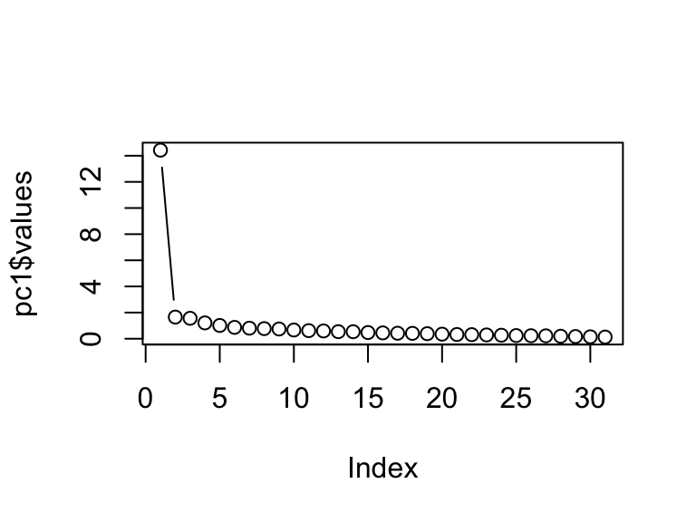

```r
#On raw data
pc1 <-  principal(internetData.2, nfactors = 31, rotate = "none")
pc1 <-  principal(internetData.2, nfactors = length(internetData.2), rotate = "none")
plot(pc1$values, type = "b")
```

```r
pc2 <-  principal(internetData.2, nfactors = 5, rotate = "none")

print.psych(pc2, cut = 0.3, sort = TRUE)
```

```
## Principal Components Analysis
## Call: principal(r = internetData.2, nfactors = 5, rotate = "none")
## Standardized loadings (pattern matrix) based upon correlation matrix
##       item  PC1   PC2   PC3   PC4   PC5   h2   u2
## ias36   31 0.80                         0.70 0.30
## ias20   19 0.79                         0.73 0.27
## ias26   23 0.77        0.35             0.78 0.22
## ias29   26 0.76                         0.69 0.31
## ias19   18 0.75                         0.66 0.34
## ias21   20 0.74                         0.66 0.34
## ias8     8 0.74                         0.61 0.39
## ias28   25 0.74        0.43             0.80 0.20
## ias10   10 0.73                         0.68 0.32
## ias9     9 0.72                         0.57 0.43
## ias24   21 0.72                         0.70 0.30
## ias12   12 0.72                         0.66 0.34
## ias18   17 0.71                         0.68 0.32
## ias33   29 0.71              0.32       0.68 0.32
## ias1     1 0.70                         0.63 0.37
## ias7     7 0.70       -0.33             0.62 0.38
## ias5     5 0.69                         0.57 0.43
## ias15   14 0.68        0.39             0.64 0.36
## ias3     3 0.68  0.40                   0.69 0.31
## ias6     6 0.67                    0.38 0.66 0.34
## ias11   11 0.67                         0.54 0.46
## ias14   13 0.67                         0.48 0.52
## ias25   22 0.66                   -0.40 0.64 0.36
## ias17   16 0.65 -0.33                   0.61 0.39
## ias30   27 0.64                         0.45 0.55
## ias35   30 0.56        0.42             0.64 0.36
## ias4     4 0.56  0.37 -0.36  0.31       0.68 0.32
## ias16   15 0.55        0.35             0.56 0.44
## ias27   24 0.53  0.33  0.32             0.51 0.49
## ias31   28 0.50  0.44       -0.42       0.64 0.36
## ias2     2 0.48  0.33        0.43  0.37 0.69 0.31
##
##                         PC1  PC2  PC3  PC4  PC5
## SS loadings           14.43 1.65 1.56 1.21 1.01
## Proportion Var         0.47 0.05 0.05 0.04 0.03
## Cumulative Var         0.47 0.52 0.57 0.61 0.64
## Proportion Explained   0.73 0.08 0.08 0.06 0.05
## Cumulative Proportion  0.73 0.81 0.89 0.95 1.00
##
## Test of the hypothesis that 5 components are sufficient.
##
## The degrees of freedom for the null model are  465  and the objective function was  21.76
## The degrees of freedom for the model are 320  and the objective function was  3.53
## The total number of observations was  207  with MLE Chi Square =  676.3  with prob <  1.2e-27
##
## Fit based upon off diagonal values = 0.99
```

### Smart Alex Task 1

```r
#load data (Figure 17.9 The Teaching of Statistics for Scientific Experiments-Revised (TOSSE-R))
setwd("~/Documents/Study/DSUR/aall_data_files")
tossData<-read.delim("tosse.r.dat", header = TRUE)
```

```r
#Create new dataset without missing data
tossData.2<-na.omit(tossData)
```

```r
#Create a correlation matrix
tossMatrix<-cor(tossData.2)
```

```r
#Bartlett's test
cortest.bartlett(tossData.2)
```

```
## $chisq
## [1] 2990
##
## $p.value
## [1] 0
##
## $df
## [1] 378
```

```r
#KMO test
kmo(tossData.2)
```

```
## $overall
## [1] 0.8941
##
## $report
## [1] "The KMO test yields a degree of common variance meritorious."
##
## $individual
##     q1     q2     q3     q4     q5     q6     q7     q8     q9    q10
## 0.9207 0.8161 0.8624 0.8654 0.8764 0.8000 0.8591 0.9435 0.9464 0.8879
##    q11    q12    q13    q14    q15    q16    q17    q18    q19    q20
## 0.9239 0.5915 0.9404 0.8773 0.8922 0.9260 0.9389 0.8905 0.8069 0.8543
##    q21    q22    q23    q24    q25    q26    q27    q28
## 0.8914 0.9025 0.8389 0.8981 0.8735 0.8959 0.8849 0.8428
##
## $AIS
```

[output cut: 292 more lines]

```r
kmo(tossData.2)$overall
```

```
## [1] 0.8941
```

```r
#Determinent:
det(cor(tossData.2))
```

```
## [1] 1.24e-06
```

```r
#PCA

#pcModel<-principal(dataframe/R-matrix, nfactors = number of factors, rotate = "method of rotation", scores = TRUE)

#On raw data
pc1 <-  principal(tossData.2, nfactors = 28, rotate = "none")
```

```r
#Extract 5 factors:
pc2 <-  principal(tossData.2, nfactors = 5, rotate = "none")
```

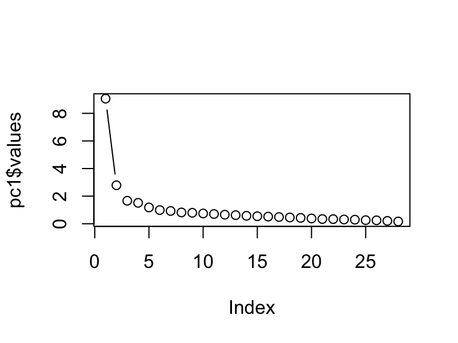

```r
#Scree plot:
plot(pc1$values, type = "b")
```

```r
#Oblique rotation on 5 factors:
pc3 <- principal(tossData.2, nfactors = 5, rotate = "oblimin")
print.psych(pc3, cut = 0.3, sort = TRUE)
```

```
## Principal Components Analysis
## Call: principal(r = tossData.2, nfactors = 5, rotate = "oblimin")
## Standardized loadings (pattern matrix) based upon correlation matrix
##     item   TC1   TC4   TC2   TC3   TC5   h2   u2
## q16   16  0.83                         0.68 0.32
## q14   14  0.81                         0.71 0.29
## q22   22  0.74                         0.77 0.23
## q17   17  0.71                         0.71 0.29
## q13   13  0.58                         0.53 0.47
## q8     8  0.54                         0.68 0.32
## q10   10  0.43                    0.41 0.42 0.58
## q24   24        0.76                   0.65 0.35
## q3     3        0.68                   0.59 0.41
## q4     4        0.60                   0.59 0.41
## q21   21  0.46  0.48                   0.57 0.43
## q1     1  0.30  0.46                   0.65 0.35
## q15   15  0.39  0.46                   0.51 0.49
## q9     9  0.33  0.37              0.35 0.64 0.36
## q19   19              0.73             0.54 0.46
## q25   25              0.67             0.55 0.45
## q20   20              0.64             0.48 0.52
## q27   27              0.57  0.39       0.62 0.38
## q26   26  0.39        0.48             0.60 0.40
## q7     7        0.38  0.45             0.49 0.51
## q11   11  0.30        0.33             0.54 0.46
## q23   23                    0.72       0.59 0.41
## q28   28                    0.70       0.54 0.46
## q5     5                    0.68       0.54 0.46
## q12   12                    0.53       0.30 0.70
## q6     6                          0.81 0.62 0.38
## q2     2                          0.75 0.62 0.38
## q18   18                    0.31  0.52 0.51 0.49
##
##                        TC1  TC4  TC2  TC3  TC5
## SS loadings           4.83 3.45 2.91 2.57 2.45
## Proportion Var        0.17 0.12 0.10 0.09 0.09
## Cumulative Var        0.17 0.30 0.40 0.49 0.58
## Proportion Explained  0.30 0.21 0.18 0.16 0.15
## Cumulative Proportion 0.30 0.51 0.69 0.85 1.00
##
##  With component correlations of
##      TC1  TC4   TC2  TC3   TC5
## TC1 1.00 0.38  0.23 0.34  0.23
## TC4 0.38 1.00  0.26 0.22  0.22
## TC2 0.23 0.26  1.00 0.13 -0.09
## TC3 0.34 0.22  0.13 1.00  0.20
## TC5 0.23 0.22 -0.09 0.20  1.00
##
## Test of the hypothesis that 5 components are sufficient.
##
## The degrees of freedom for the null model are  378  and the objective function was  13.6
## The degrees of freedom for the model are 248  and the objective function was  2.49
## The total number of observations was  231  with MLE Chi Square =  539.3  with prob <  1.1e-23
##
## Fit based upon off diagonal values = 0.97
```

```r
#Oblique rotation on 3 factors:
pc4 <- principal(tossData.2, nfactors = 3, rotate = "oblimin")
print.psych(pc4, cut = 0.3, sort = TRUE)
```

```
## Principal Components Analysis
## Call: principal(r = tossData.2, nfactors = 3, rotate = "oblimin")
## Standardized loadings (pattern matrix) based upon correlation matrix
##     item   TC1   TC2   TC3   h2   u2
## q22   22  0.84             0.70 0.30
## q17   17  0.79             0.64 0.36
## q9     9  0.76             0.63 0.37
## q8     8  0.73             0.67 0.33
## q1     1  0.72             0.59 0.41
## q13   13  0.70             0.50 0.50
## q21   21  0.69             0.52 0.48
## q15   15  0.58             0.35 0.65
## q4     4  0.58             0.38 0.62
## q3     3  0.55  0.35       0.46 0.54
## q24   24  0.53             0.42 0.58
## q10   10  0.51             0.32 0.68
## q16   16  0.51             0.43 0.57
## q2     2  0.48 -0.44       0.43 0.57
## q6     6  0.48 -0.44       0.35 0.65
## q14   14  0.43        0.33 0.42 0.58
## q19   19        0.65       0.42 0.58
## q26   26        0.65       0.55 0.45
## q25   25        0.59       0.47 0.53
## q27   27        0.58  0.40 0.59 0.41
## q20   20        0.49       0.36 0.64
## q7     7  0.41  0.48       0.46 0.54
## q11   11  0.38  0.44       0.54 0.46
## q5     5              0.70 0.53 0.47
## q23   23              0.70 0.52 0.48
## q28   28              0.66 0.48 0.52
## q12   12              0.56 0.29 0.71
## q18   18  0.38 -0.38  0.39 0.48 0.52
##
##                        TC1  TC2  TC3
## SS loadings           7.38 3.44 2.69
## Proportion Var        0.26 0.12 0.10
## Cumulative Var        0.26 0.39 0.48
## Proportion Explained  0.55 0.25 0.20
## Cumulative Proportion 0.55 0.80 1.00
##
##  With component correlations of
##      TC1  TC2  TC3
## TC1 1.00 0.22 0.41
## TC2 0.22 1.00 0.05
## TC3 0.41 0.05 1.00
##
## Test of the hypothesis that 3 components are sufficient.
##
## The degrees of freedom for the null model are  378  and the objective function was  13.6
## The degrees of freedom for the model are 297  and the objective function was  3.3
## The total number of observations was  231  with MLE Chi Square =  718.8  with prob <  5.8e-37
##
## Fit based upon off diagonal values = 0.96
```

### Smart Alex Task 2

```r
#Load data (FIGURE 17.10 Williams’s organizational ability questionnaire)
setwd("~/Documents/Study/DSUR/aall_data_files")
williamsData<-read.delim("Williams.dat", header = TRUE)
```

```r
#Create new dataset without missing data
williamsData.1<-na.omit(williamsData)

williamsData.2<-williamsData.1[,1]+williamsData.1[,4:31]
```

```r
#Create a correlation matrix
williamsMatrix<-cor(williamsData.2)
```

```r
#Bartlett's test
cortest.bartlett(williamsData.2)
```

```
## $chisq
## [1] 54391
##
## $p.value
## [1] 0
##
## $df
## [1] 378
```

```r
#KMO test
kmo(williamsData.2)
```

```
## $overall
## [1] 0.9878
##
## $report
## [1] "The KMO test yields a degree of common variance marvelous."
##
## $individual
##   org1   org2   org3   org4   org6   org7   org9  org10  org11  org12
## 0.9886 0.9859 0.9830 0.9836 0.9904 0.9882 0.9846 0.9890 0.9912 0.9902
##  org13  org14  org16  org17  org18  org19  org20  org21  org22  org23
## 0.9884 0.9906 0.9913 0.9833 0.9892 0.9900 0.9886 0.9916 0.9901 0.9878
##  org24  org25  org26  org27  org28  org29  org30  org31
## 0.9839 0.9803 0.9880 0.9875 0.9889 0.9889 0.9864 0.9885
##
## $AIS
```

[output cut: 292 more lines]

```r
#Calculate the Determinent:
det(cor(williamsData.2))
```

```
## [1] 3.632e-109
```

```r
#PCA
#pcModel
#On raw data, extract 5 factors, varimax rotation:
pc1 <-  principal(williamsData.2, nfactors = 5, rotate = "varimax")
```

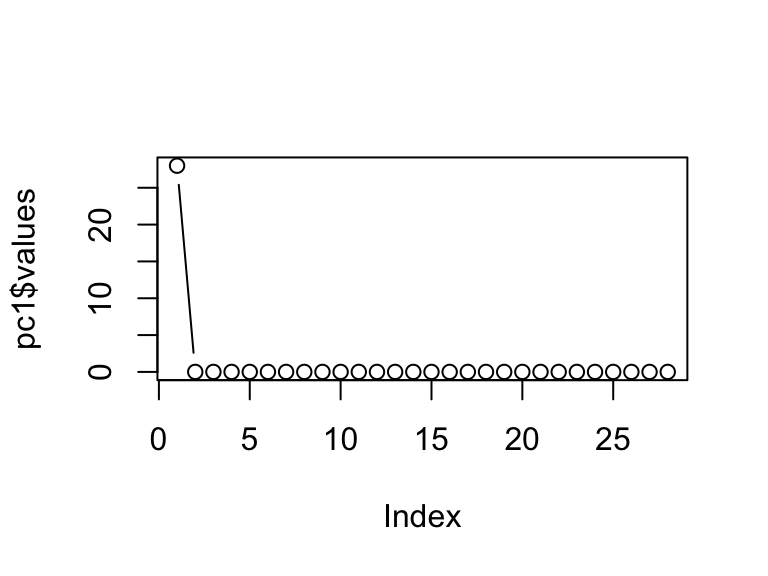

```r
#Scree plot:
plot(pc1$values, type = "b")
```

```r
#Pattern Matrix in a nice format:
print.psych(pc1, cut = 0.3, sort = TRUE)
```

```
## Principal Components Analysis
## Call: principal(r = williamsData.2, nfactors = 5, rotate = "varimax")
## Standardized loadings (pattern matrix) based upon correlation matrix
##       item  RC2  RC4  RC3  RC5  RC1 h2      u2
## org22   19 0.57 0.54 0.49            1 7.2e-05
## org29   26 0.57 0.54 0.49            1 6.5e-05
## org28   25 0.57 0.54 0.49            1 7.2e-05
## org30   27 0.57 0.54 0.49            1 6.4e-05
## org14   12 0.57 0.54 0.49            1 9.7e-05
## org23   20 0.57 0.54 0.49            1 7.3e-05
## org9     7 0.57 0.54 0.49            1 5.7e-05
## org13   11 0.57 0.54 0.50            1 9.0e-05
## org31   28 0.57 0.54 0.49            1 7.8e-05
## org3     3 0.56 0.54 0.49 0.30       1 4.7e-05
## org27   24 0.56 0.54 0.49 0.30       1 5.3e-05
## org4     4 0.56 0.54 0.49 0.30       1 6.2e-05
## org6     5 0.56 0.54 0.49            1 7.0e-05
## org19   16 0.56 0.53 0.50            1 5.5e-05
## org26   23 0.56 0.54 0.49            1 7.3e-05
## org10    8 0.56 0.54 0.50            1 4.5e-05
## org24   21 0.56 0.54 0.49 0.30       1 5.9e-05
## org16   13 0.56 0.54 0.50            1 7.0e-05
## org17   14 0.56 0.54 0.50            1 4.8e-05
## org20   17 0.56 0.54 0.50            1 4.2e-05
## org12   10 0.56 0.54 0.49            1 1.0e-04
## org25   22 0.56 0.54 0.50            1 3.5e-05
## org11    9 0.56 0.54 0.49            1 4.9e-05
## org21   18 0.56 0.55 0.49            1 7.5e-05
## org7     6 0.56 0.54 0.49            1 6.4e-05
## org1     1 0.56 0.54 0.50 0.30       1 6.0e-05
## org18   15 0.56 0.54 0.50 0.30       1 6.6e-05
## org2     2 0.56 0.55 0.49            1 6.4e-05
##
##                        RC2  RC4  RC3  RC5  RC1
## SS loadings           8.89 8.15 6.82 2.48 1.65
## Proportion Var        0.32 0.29 0.24 0.09 0.06
## Cumulative Var        0.32 0.61 0.85 0.94 1.00
## Proportion Explained  0.32 0.29 0.24 0.09 0.06
## Cumulative Proportion 0.32 0.61 0.85 0.94 1.00
##
## Test of the hypothesis that 5 components are sufficient.
##
## The degrees of freedom for the null model are  378  and the objective function was  249.7
## The degrees of freedom for the model are 248  and the objective function was  2.84
## The total number of observations was  229  with MLE Chi Square =  609.8  with prob <  1.9e-32
##
## Fit based upon off diagonal values = 1
```